# Behavioural Data Analysis

J. Pablo Franco, Nitin Yadav, Peter Bossaerts, Carsten Murawski

17 July, 2020

This document contains code used to analyse the behavioural data after preprocessing.

**Important note on terminology:**

1. What we refer to in the main manuscript as Typical-case Complexity (TCC) is referred to here as Instance complexity or in relation to its proximity to the phase transition (`phaseT`):
   - `In the phase transition` refers to high TCC and `Out of the phase transition` refers to low TCC.
   - `high Instance Complexity(IC)` refers to high TCC and `low Instance Complexity(IC)` refers to low TCC.

```r
## Setting up the basics
library(ggplot2)
library(lme4)
library(stargazer)
library(knitr)
library(ggsignif)
library(plotrix)
library(stringr)
library(readr)
library(fuzzyjoin)
library(tibble)
```

```r
#Folder Setup
if(dir.exists("/Volumes/GoogleDrive/My Drive/")){
  mother_folder = "/Volumes/GoogleDrive/My Drive/"
} else {
  mother_folder = "~/Google Drive/"
}

project_folder = paste0(mother_folder,"Melbourne/UNIMELB/Research/Complexity Project/")
folder = paste0(project_folder,"KS-IC/Code/Behavioural-Analysis/PNAS")

setwd(folder)
knitr::opts_knit$set(root.dir = folder)

#Input Parameters
#source(paste0(folder,"/Input/Behav_IC/V1.R"))
data_type="Work Data" #Directing to the right folder Raw Data or Work data
experiment="Exp" #e.g. "Pilot","Exp"
versions=c("V4") #c("imV1")

# Import Data Folders
folderData=paste0(project_folder,"KS-IC/Data/Behav/",data_type,"/",experiment,"/processed/")

#Decision Data
fileDataDec=paste0(folderData,"KSDec_clean.csv")

#Optimisation Data
fileDataOpt=paste0(folderData,"KSOpt_clean.csv")

#Optimisation Data  for time analysis
fileDataOpt_time=paste0(folderData,"KSOpt_time_clean.csv")

#Click-Optimisation Data
fileDataClicks=paste0(folderData,"KSOpt_clicks_clean.csv")

#Arithmetic Data Text files
fileDataMath=paste0(folderData,"MATH_clean.csv")

#CANTAB Data Text Files
fileDataCantab=paste0(folderData,"CANTAB_clean.csv")

#This requires all the data from simulations (Not on Github due to file size)
#Instances Data Text files
folderInstanceInfo=paste0(project_folder,"Simulations Data/")
fileDecInstancesAll = paste0(folderInstanceInfo,'KS decision/decisionInstancesInfo.csv')



optTaskMaxTime=60

#Output type for tables. Use "html" to view the output .html file and use "latex" to export .tex tables
outputType="html"
```

```r
#Import functions
source(paste0(folder, "/DescriptiveFunctions.R"))

#Stores a list of all the regressions that are run
allModels=vector("list", length=0)

#' Create the formatted table for statistical model export
#'
#' @param model model to be exported
#' @param title Caption shown aththe top of the table
#' @param outputType "html" or "latex"
#' @param outputName The name of the output file
#'
#' @return The text of the table
#' @export table Exports tables if outputType==Latex
modelTableStyle = function(model,title,outputType,outputName){
  print(outputName)
  # Stores the model in the list with all the models
  allModels[[outputName]]<<-model
  if (outputType=="html"){
      table = stargazer(model, type=outputType, report=('vc*sp'),#(('vc*p'))
                        column.labels=c("Random Intercept"), dep.var.caption = title,
                        dep.var.labels.include = TRUE,model.names=FALSE,
                        align=TRUE, column.sep.width = "5000pt")
  } else if (outputType=="latex"){
          table = stargazer(model, type=outputType, report=('vc*sp'),
                            column.labels=c("Random Intercept"), dep.var.caption = title,
                            dep.var.labels.include = TRUE,model.names=FALSE, align=TRUE,
                            column.sep.width = "0pt",
                            out = paste0("Output/Tables/",outputName,".tex"),table.placement="H")
  }
  #return(table)
}

#' Exports the formatted plot as pdf for report
#' @param plot The ggplot to be exported
#' @param outputName The name of the output file
#'
#' @return
#' @export plot formatted plot as pdf
plotExport = function(plot,outputName){
  print(outputName)
  print(plot)
  path = "/Output/Figures/"
  print(folder)
  #folder="~/Google Drive/Melbourne/UNIMELB/Research/Complexity Project/KS-IC/Code/Behavioural-Analysis"
  pdf(file=paste0(folder,path,outputName,".pdf"))
  print(plot)
  dev.off()
}

plotExport2 = function(plot,outputName, height=3, width=4, units="in", type = "pdf"){
  path = "/Output/Figures/"
  ggsave(paste0(folder,path,outputName,".",type),
         plo,height=height,width=width,units = units)
}

#' Export non-regression-based table to html or latex using Pander
#'
#' @param table The table to be formated
#' @param title Caption shown ath the top of the table
#' @param outputType html" or "latex"
#' @param outputName The name of the output file
#'
#' @return The formatted text of the table
#' @export table Exports tables if outputType==Latex
exportTable = function(table,title,outputType,outputName){
  print(outputName)
  if (outputType=="html"){
      table = stargazer(table, type=outputType, dep.var.caption = title, align=TRUE,
                        column.sep.width = "5000pt",summary=FALSE,rownames = FALSE)
  } else if (outputType=="latex"){
          table = stargazer(table, type=outputType, dep.var.caption = title, align=TRUE,
                            column.sep.width = "0pt",
                            out = paste0("Output/Tables/",outputName,".tex"),
                            table.placement="H",
                          summary=FALSE,rownames = FALSE)
  }
}
```

# 1 Knapsack Decision Variant

```r
#Imports Decision Data
dataDecProp = read_csv(fileDataDec)
# Generates summary of KS decision data
summaryListDec= summaryData(dataDecProp)
```

## 1.1 Descriptive Summary

```r
print(paste('Participants To be analysed are:',paste(sort(unique(dataDecProp$pID)),collapse=" ")))
```

```
[1] "Participants To be analysed are: be14 be15 be16 be17 be18 be19 be20 be21 be22 be23 be24 be25 be26 be27 be28 be29 be30 be31 be32 be33"
```

```r
print(paste('Number of participants to analyse :',length(unique(dataDecProp$pID)) ) )
```

```
[1] "Number of participants to analyse : 20"
```

```r
print(paste("The overall Accuracy was: ",mean(dataDecProp$correct)))
```

```
[1] "The overall Accuracy was:  0.831114225648213"
```

```r
#Summary Stats for Decision Problem
dataInput=dataDecProp

accuracySummary = dataInput %>% group_by(pID) %>% summarise(acc=mean(correct)) %>% summarise(mean=mean(acc),min=min(acc),max=max(acc),SD=sd(acc))
```

`summarise()` ungrouping output (override with `.groups` argument)

```r
kable(accuracySummary, digits=2, caption = "Accuracy Summary")
```

| mean | min | max | SD |
| --- | --- | --- | --- |
| 0.83 | 0.56 | 0.9 | 0.08 |

```r
answerSummary = dataInput %>% group_by(pID) %>% summarise(acc=mean(answer)) %>% summarise(mean=mean(acc),min=min(acc),max=max(acc),SD=sd(acc))
```

`summarise()` ungrouping output (override with `.groups` argument)

```r
kable(answerSummary, digits=2, caption = "Proportion of times that YES was selected as the answer")
```

| mean | min | max | SD |
| --- | --- | --- | --- |
| 0.48 | 0.31 | 0.6 | 0.06 |

```r
yesNoProportions = dataInput %>% group_by(sol,pID) %>% summarise(acc=mean(correct)) %>% summarise(mean=mean(acc),min=min(acc),max=max(acc),SD=sd(acc))
```

`summarise()` regrouping output by ‘sol’ (override with `.groups` argument) `summarise()` ungrouping output (override with `.groups` argument)

```r
kable(yesNoProportions, digits=2, caption = "Accuracy By Solution")
```

| sol | mean | min | max | SD |
| --- | --- | --- | --- | --- |
| 0 | 0.85 | 0.69 | 0.97 | 0.08 |
| 1 | 0.81 | 0.36 | 0.89 | 0.12 |

```r
NA
```

### 1.1.1 Effect of Trial number on accuracy (Computational Performance)

```r
#Trial (experience effect) effect

#Summary
summaryByBlock = dataInput %>% group_by(block,pID) %>% summarise(acc=mean(correct)) %>% summarise(mean=mean(acc),min=min(acc),max=max(acc),SD=sd(acc))
```

`summarise()` regrouping output by ‘block’ (override with `.groups` argument) `summarise()` ungrouping output (override with `.groups` argument)

```r
kable(summaryByBlock, digits=2, caption = "Accuracy By Block Number")
```

| block | mean | min | max | SD |
| --- | --- | --- | --- | --- |
| 1 | 0.83 | 0.62 | 1.00 | 0.10 |
| 2 | 0.83 | 0.50 | 0.96 | 0.11 |
| 3 | 0.83 | 0.42 | 0.96 | 0.11 |

```r
#Regresssion
dataInput=dataDecProp
dataInput$totalTrial = dataInput$block * dataInput$trial

logitRandomIntercept = glmer(correct ~ totalTrial+ (1|pID), family=binomial(link="logit"), data=dataInput)

title="Logistic regressions"
tableName='dec01r'
modelTableStyle(logitRandomIntercept,title,outputType,tableName)
```

[1] “dec01r” length of NULL cannot be changedlength of NULL cannot be changedlength of NULL cannot be changedlength of NULL cannot be changedlength of NULL cannot be changed

|  | Logistic regressions |
| --- | --- |
|  | correct |
|  | Random Intercept |
| totalTrial | 0.005 |
|  | (0.004) |
|  | p = 0.196 |
| Constant | 1.516*** |
|  | (0.150) |
|  | p = 0.000 |
| Observations | 1,427 |
| Log Likelihood | -639.577 |
| Akaike Inf. Crit. | 1,285.153 |
| Bayesian Inf. Crit. | 1,300.943 |
| *Note:* | p<0.1; p<0.05; p<0.01 |

## 1.2 In and Out of Phase Transition Contrast

### 1.2.1 Accuracy Contrast (Computational Performance)

```
[1] "dec02g"
[1] "/Volumes/GoogleDrive/My Drive/Melbourne/UNIMELB/Research/Complexity Project/KS-IC/Code/Behavioural-Analysis/PNAS"
quartz_off_screen
                2
```

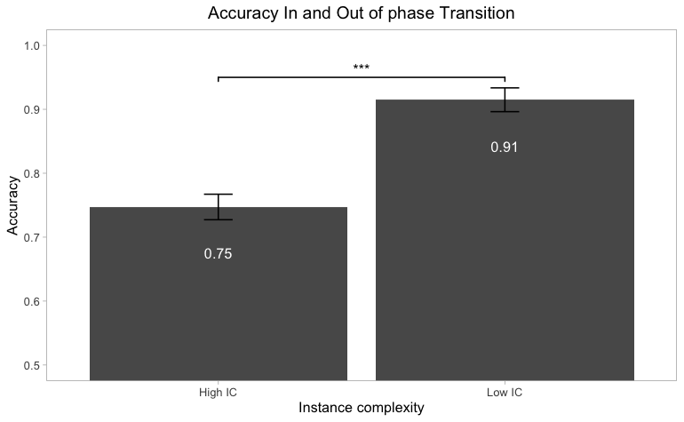

```r
dataInput=dataDecProp %>% group_by(phaseT,pID)%>%summarise(accuracy1=mean(correct))%>%ungroup()%>%group_by(phaseT)%>%summarise(accuracy=mean(accuracy1),se=se(accuracy1))%>%ungroup()
dataInput$phaseT = recode(dataInput$phaseT, '0' = "Low IC", '1' = "High IC")

plo= ggplot(data=dataInput, aes(y=accuracy, x=as.factor(phaseT),label = round(accuracy,digits = 2))) +
  geom_bar(stat = "identity")+
  geom_errorbar(aes(ymin=accuracy-se, ymax=accuracy+se), width=.1)+
  geom_signif(comparisons = list(c("Low IC","High IC")), annotations="***", y_position = 0.95, tip_length = 0.03)+
  labs(title="Accuracy In and Out of phase Transition",x="Instance complexity",y="Accuracy")+
  coord_cartesian(ylim = c(0.5,1))+
  geom_text(hjust=0.5,vjust = 5, colour="white") +
  theme_light()+
  theme(panel.grid.major = element_blank(), panel.grid.minor = element_blank(),plot.title = element_text(hjust = 0.5))

outputName = "dec02g"
plotExport(plo,outputName)
```

```r
#Anova contrast for In/Out Phase transition
anovaModel=aov(correct~phaseT+Error(pID/phaseT),dataDecProp)
anovaPValue=summary(anovaModel)[[2]][[1]][['Pr(>F)']][[1]]
print(paste("P-value for one way ANOVA:",signif(anovaPValue,digits=3)))
```

[1] “P-value for one way ANOVA: 3.58e-09”

```r
rm(dataInput)
```

```r
#Logistic Regression for In/Out Phase transition

#logistic with random effects (intercept)
logitRandomIntercept = glmer(correct ~ phaseT + (1|pID), family=binomial(link="logit"), data=dataDecProp)

title="Logistic regressions"
tableName='dec02r'
modelTableStyle(logitRandomIntercept,title,outputType,tableName)
```

[1] “dec02r” length of NULL cannot be changedlength of NULL cannot be changedlength of NULL cannot be changedlength of NULL cannot be changedlength of NULL cannot be changed

|  | Logistic regressions |
| --- | --- |
|  | correct |
|  | Random Intercept |
| phaseT | -1.327*** |
|  | (0.161) |
|  | p = 0.000 |
| Constant | 2.451*** |
|  | (0.167) |
|  | p = 0.000 |
| Observations | 1,427 |
| Log Likelihood | -602.372 |
| Akaike Inf. Crit. | 1,210.744 |
| Bayesian Inf. Crit. | 1,226.534 |
| *Note:* | p<0.1; p<0.05; p<0.01 |

### 1.2.2 Satisfiability and Phase Transition

#### 1.2.2.1 Is Phase Transition still significant regardless of the instance being satisfiable or not?

```
[1] "dec03g"
[1] "/Volumes/GoogleDrive/My Drive/Melbourne/UNIMELB/Research/Complexity Project/KS-IC/Code/Behavioural-Analysis/PNAS"
quartz_off_screen
                2
```

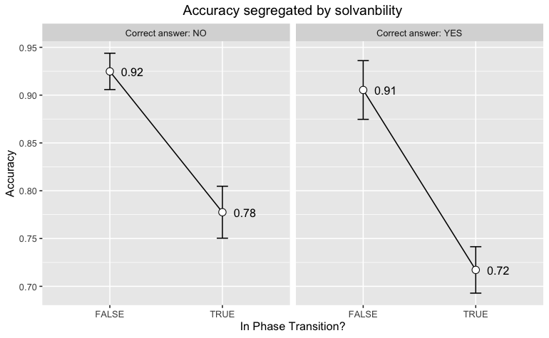

```r
dataInput=dataDecProp %>% group_by(phaseT,sol,pID)%>%summarise(accuracy1=mean(correct))%>%ungroup()%>%group_by(sol,phaseT)%>%summarise(accuracy=mean(accuracy1),se=se(accuracy1))%>%ungroup()
sol_names <- c(
                    `0` = "Correct answer: NO",
                    `1` = "Correct answer: YES",
                    `2` = "If this is here it means data not filtered"
                    )

plo=ggplot(data=dataInput, aes(y=accuracy, x=as.factor(as.logical(phaseT)), label = round(accuracy,digits = 2),group=1)) +
  geom_line()+
  geom_errorbar(aes(ymin=accuracy-se, ymax=accuracy+se), width=.1) +
  geom_point(shape=21, size=3, fill="white")+
  labs(title="Accuracy segregated by solvanbility",x="In Phase Transition?",y="Accuracy")+
  theme(plot.title = element_text(hjust = 0.5), axis.text.x = element_text(angle=0,hjust=0.5))+
  geom_text(hjust=-0.5, colour="black")+
  facet_grid(.~sol, labeller = as_labeller(sol_names))

outputName = "dec03g"
plotExport(plo,outputName)
```

```r
#logistic with random effects (intercept)
logitRandomIntercept = glmer(correct ~ phaseT + sol + phaseT:sol + (1|pID), family=binomial(link="logit"), data=dataDecProp)

title="Logistic regressions"
tableName='dec03r'
modelTableStyle(logitRandomIntercept,title,outputType,tableName)
```

[1] “dec03r” length of NULL cannot be changedlength of NULL cannot be changedlength of NULL cannot be changedlength of NULL cannot be changedlength of NULL cannot be changed

|  | Logistic regressions |
| --- | --- |
|  | correct |
|  | Random Intercept |
| phaseT | -1.285*** |
|  | (0.240) |
|  | p = 0.00000 |
| sol | -0.250 |
|  | (0.271) |
|  | p = 0.355 |
| phaseT:sol | -0.084 |
|  | (0.323) |
|  | p = 0.796 |
| Constant | 2.584*** |
|  | (0.224) |
|  | p = 0.000 |
| Observations | 1,427 |
| Log Likelihood | -600.149 |
| Akaike Inf. Crit. | 1,210.299 |
| Bayesian Inf. Crit. | 1,236.615 |
| *Note:* | p<0.1; p<0.05; p<0.01 |

### 1.2.3 Phase Transition effect by Region (Over-Under-InPT)

#### 1.2.3.1 Is Phase Transition is significant irregardless of region (OverConstrained/Underconstrained)?

```
[1] "decB01g"
[1] "/Volumes/GoogleDrive/My Drive/Melbourne/UNIMELB/Research/Complexity Project/KS-IC/Code/Behavioural-Analysis/PNAS"
quartz_off_screen
                2
```

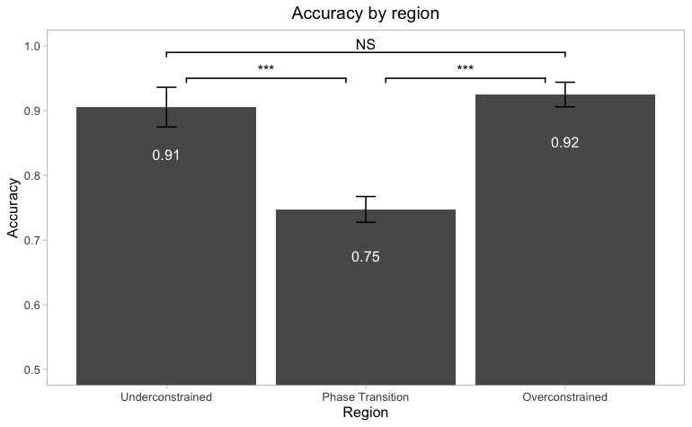

```r
dataInput=dataDecProp %>% mutate(region=recode(type, `1`= 'Phase Transition', `2`= 'Phase Transition', `3`= 'Phase Transition', `4`='Phase Transition', '5'='Overconstrained', '6'='Underconstrained'))

dataInput2=dataInput %>% group_by(region,pID)%>%summarise(accuracy1=mean(correct))%>%ungroup()%>%group_by(region)%>%summarise(accuracy=mean(accuracy1),se=se(accuracy1))%>%ungroup()
dataInput2$region <- factor(dataInput2$region, levels = c('Underconstrained',
                                                          'Phase Transition',
                                                          'Overconstrained'))

plo= ggplot(data=dataInput2, aes(y=accuracy, x=region, label = round(accuracy,digits = 2))) +
  geom_bar(stat = "identity")+
  geom_signif(annotations = c("***","***"),
              y_position=c(0.95,0.95),xmin=c(1.1,2.1),xmax=c(1.9,2.9))+
  geom_signif(comparisons = list(c("Underconstrained","Overconstrained")),
               annotations="NS", y_position = 0.99, tip_length = 0.03)+
  geom_errorbar(aes(ymin=accuracy-se, ymax=accuracy+se), width=.1)+
  labs(title="Accuracy by region",x="Region",y="Accuracy")+
  coord_cartesian(ylim = c(0.5,1))+
  geom_text(hjust=0.5,vjust = 5, colour="white") +
  theme_light()+
  theme(panel.grid.major = element_blank(), panel.grid.minor = element_blank(),plot.title = element_text(hjust = 0.5))

outputName = "decB01g"
plotExport(plo,outputName)
```

```r
#Stats test for time in and out of phase transition: ANOVA
dataInput$overConstrained= (dataInput$region=='Overconstrained')
dataInput$underConstrained= (dataInput$region=='Underconstrained')
```

```r
logitRandomIntercept = glmer(correct ~ overConstrained + underConstrained + (1|pID), family=binomial(link="logit"), data=dataInput)

title="Logistic regressions"
tableName="decB01r1"
modelTableStyle(logitRandomIntercept,title,outputType,tableName)
```

[1] “decB01r1” length of NULL cannot be changedlength of NULL cannot be changedlength of NULL cannot be changedlength of NULL cannot be changedlength of NULL cannot be changed

|  | Logistic regressions |
| --- | --- |
|  | correct |
|  | Random Intercept |
| overConstrained | 1.459*** |
|  | (0.220) |
|  | p = 0.000 |
| underConstrained | 1.208*** |
|  | (0.202) |
|  | p = 0.000 |
| Constant | 1.125*** |
|  | (0.130) |
|  | p = 0.000 |
| Observations | 1,427 |
| Log Likelihood | -601.946 |
| Akaike Inf. Crit. | 1,211.891 |
| Bayesian Inf. Crit. | 1,232.944 |
| *Note:* | p<0.1; p<0.05; p<0.01 |

```r
rm(logit)
```

object ‘logit’ not found

```r
logitRandomIntercept = glmer(correct ~ overConstrained + phaseT + (1|pID), family=binomial(link="logit"), data=dataInput)

title="Logistic regressions"
tableName="decB01r2"
modelTableStyle(logitRandomIntercept,title,outputType,tableName)
```

[1] “decB01r2” length of NULL cannot be changedlength of NULL cannot be changedlength of NULL cannot be changedlength of NULL cannot be changedlength of NULL cannot be changed

|  | Logistic regressions |
| --- | --- |
|  | correct |
|  | Random Intercept |
| overConstrained | 0.250 |
|  | (0.271) |
|  | p = 0.355 |
| phaseT | -1.208*** |
|  | (0.202) |
|  | p = 0.000 |
| Constant | 2.333*** |
|  | (0.206) |
|  | p = 0.000 |
| Observations | 1,427 |
| Log Likelihood | -601.946 |
| Akaike Inf. Crit. | 1,211.891 |
| Bayesian Inf. Crit. | 1,232.944 |
| *Note:* | p<0.1; p<0.05; p<0.01 |

```r
rm(logit)
```

object ‘logit’ not found

## 1.3 MZN Propagations and accuracy (Computational Performance)

```
[1] "dec04g"
[1] "/Volumes/GoogleDrive/My Drive/Melbourne/UNIMELB/Research/Complexity Project/KS-IC/Code/Behavioural-Analysis/PNAS"
quartz_off_screen
                2
```

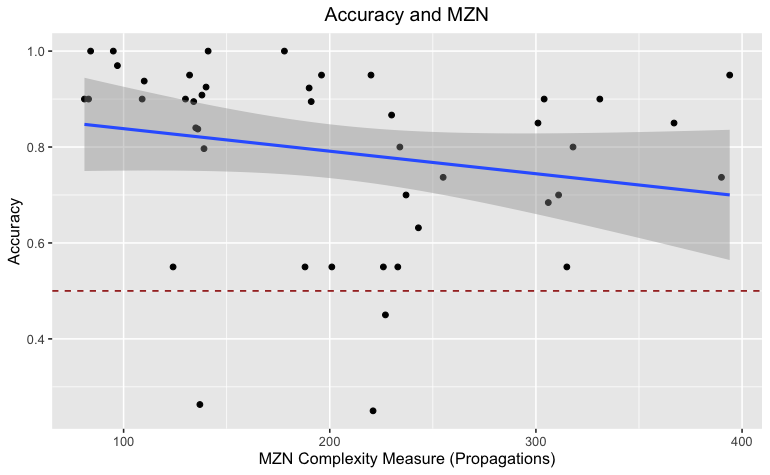

```r
#MZN Propagations
groups4=dataDecProp  %>% group_by(propagations)
dat4=summarise(groups4, accuracy=mean(correct), se=se(correct))
plo = ggplot(data=dat4, aes(y=accuracy, x=propagations)) +
  geom_point()+
  labs(title="Accuracy and MZN",y="Accuracy",x="MZN Complexity Measure (Propagations)")+
  theme(plot.title = element_text(hjust = 0.5)) +
  #geom_smooth(method = lm)+
  #stat_smooth(method = glm, method.args = list(family=binomial(link="logit")))+
  stat_smooth(method = glm)+
  geom_hline(aes(yintercept=0.5), colour="#990000", linetype="dashed")

outputName = "dec04g"
plotExport(plo,outputName)
```

```r
logitRandomIntercept = glmer(correct ~ scale(propagations) + (1|pID), family=binomial(link="logit"), data=dataDecProp)
#summary(logitRandomInterceptSlope)

title="Logistic regressions"
tableName='dec04r'
modelTableStyle(logitRandomIntercept,title,outputType,tableName)
```

[1] “dec04r” length of NULL cannot be changedlength of NULL cannot be changedlength of NULL cannot be changedlength of NULL cannot be changedlength of NULL cannot be changed

|  | Logistic regressions |
| --- | --- |
|  | correct |
|  | Random Intercept |
| scale(propagations) | -0.362*** |
|  | (0.066) |
|  | p = 0.00000 |
| Constant | 1.689*** |
|  | (0.118) |
|  | p = 0.000 |
| Observations | 1,427 |
| Log Likelihood | -626.120 |
| Akaike Inf. Crit. | 1,258.240 |
| Bayesian Inf. Crit. | 1,274.030 |
| *Note:* | p<0.1; p<0.05; p<0.01 |

```r
rm(logit2)
```

object ‘logit2’ not found

## 1.4 SAT Decisions and Accuracy (Computational Performance)

```
[1] "dec05g"
[1] "/Volumes/GoogleDrive/My Drive/Melbourne/UNIMELB/Research/Complexity Project/KS-IC/Code/Behavioural-Analysis/PNAS"
quartz_off_screen
                2
```

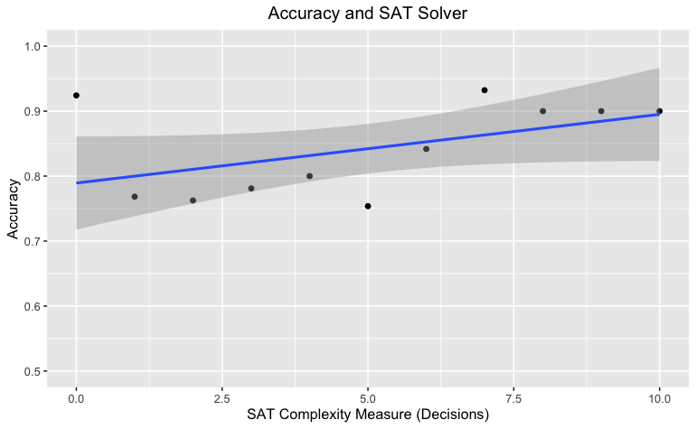

```r
groups5=dataDecProp %>% group_by(decisions)
dat5=summarise(groups5, accuracy=mean(correct), se=se(correct))
plo = ggplot(data=dat5, aes(y=accuracy, x=decisions)) +
  geom_point()+
  labs(title="Accuracy and SAT Solver",y="Accuracy",x="SAT Complexity Measure (Decisions)")+
  theme(plot.title = element_text(hjust = 0.5)) +
  #stat_smooth(method = glm, method.args = list(family=binomial(link="logit")))+
  geom_smooth(method = glm) +
  coord_cartesian(ylim = c(0.50,1.00))

outputName = "dec05g"
plotExport(plo,outputName)
```

```r
logitRandomIntercept = glmer(correct ~ decisions + (1|pID), family=binomial(link="logit"), data=dataDecProp)

title="Logistic regressions"
tableName='dec05r'
modelTableStyle(logitRandomIntercept,title,outputType,tableName)
```

[1] “dec05r” length of NULL cannot be changedlength of NULL cannot be changedlength of NULL cannot be changedlength of NULL cannot be changedlength of NULL cannot be changed

|  | Logistic regressions |
| --- | --- |
|  | correct |
|  | Random Intercept |
| decisions | -0.022 |
|  | (0.026) |
|  | p = 0.395 |
| Constant | 1.714*** |
|  | (0.142) |
|  | p = 0.000 |
| Observations | 1,427 |
| Log Likelihood | -640.066 |
| Akaike Inf. Crit. | 1,286.131 |
| Bayesian Inf. Crit. | 1,301.921 |
| *Note:* | p<0.1; p<0.05; p<0.01 |

## 1.5 Number of Solutions that satisfy the Constraints and Accuracy (Computational Performance)

```
[1] "decB02g"
[1] "/Volumes/GoogleDrive/My Drive/Melbourne/UNIMELB/Research/Complexity Project/KS-IC/Code/Behavioural-Analysis/PNAS"
quartz_off_screen
                2
```

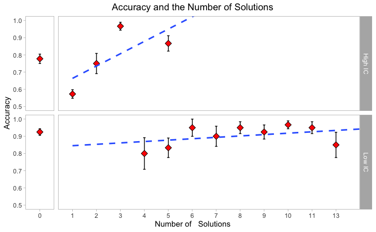

```r
dataInput=dataDecProp
#dataInput=nSolutions(dataInput)

#Plots nSolutions (x) vs. Accuracy (y)
dataInput3 = dataInput %>% group_by(nSolutions,pID,phaseT)%>%summarise(accuracyMeans=mean(correct))%>%ungroup()%>%group_by(nSolutions,phaseT)%>%summarise(accuracy=mean(accuracyMeans),se=se(accuracyMeans))%>%ungroup()
dataInput3$sol = dataInput3$nSolutions>=1
dataInput3$phaseT = recode(dataInput3$phaseT, '0' = "Low IC", '1' = "High IC")

plo= ggplot(data=dataInput3, aes(y=accuracy, x=as.factor(nSolutions))) +
  geom_errorbar(aes(ymin=accuracy-se, ymax=accuracy+se), width=.1)+
  geom_point(shape=23, size=3, fill="red")+
  labs(title="Accuracy and the Number of Solutions",
       x="Number of   Solutions",y="Accuracy")+
  coord_cartesian(ylim = c(0.5,1))+
  theme_light()+
  theme(panel.grid.major = element_blank(), panel.grid.minor = element_blank(),
        plot.title = element_text(hjust = 0.5),strip.text.x = element_blank())+
  facet_grid(phaseT~sol, scales = "free_x", space = "free_x")+
  geom_smooth(data=dataInput3, aes(y=accuracy, x=nSolutions),method=glm,se=FALSE,fullrange=TRUE,linetype = "dashed")

outputName = "decB02g"
plotExport(plo,outputName)
```

```r
#Number of solutions of solvable solutions: Mean difference between In/Out of Phase T
library(pander)
dataInput2 = unique(dataInput %>% select(phaseT,id,nSolutions,sol) %>% filter(sol==1))
diffMeans = t.test(nSolutions ~ phaseT ,data=dataInput2)
pander(diffMeans)
```

```
-------------------------------------------------------------------
 Test statistic    df         P value       Alternative hypothesis
---------------- ------- ----------------- ------------------------
     8.428        26.36   5.879e-09 * * *         two.sided
-------------------------------------------------------------------

Table: Welch Two Sample t-test: `nSolutions` by `phaseT` (continued below)


-----------------------------------
 mean in group 0   mean in group 1
----------------- -----------------
      8.389             2.167
-----------------------------------
```

Remake of the plot for publication

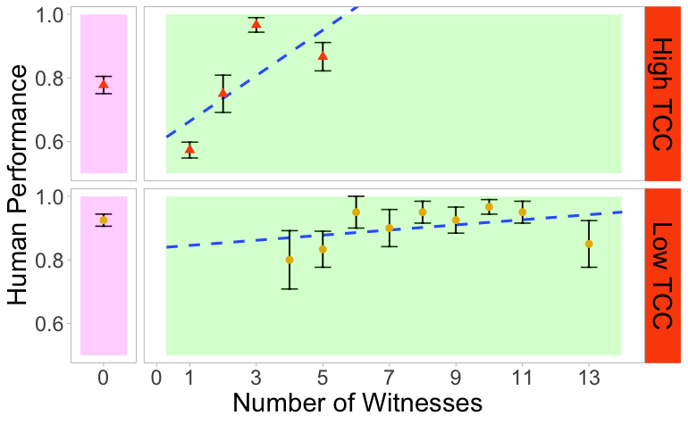

```r
dataInput=dataDecProp
#dataInput=nSolutions(dataInput)

#Plots nSolutions (x) vs. Accuracy (y)
dataInput3 = dataInput %>% group_by(nSolutions,pID,phaseT)%>%summarise(accuracyMeans=mean(correct))%>%ungroup()%>%group_by(nSolutions,phaseT)%>%summarise(accuracy=mean(accuracyMeans),se=se(accuracyMeans))%>%ungroup()
dataInput3$sol = dataInput3$nSolutions>=1
dataInput3$phaseT = recode(dataInput3$phaseT, '0' = "Low TCC", '1' = "High TCC")
dataInput3$phaseT = as.factor(dataInput3$phaseT)

size_big = 20
size_small = 16
dataInput3$nSolutions2=dataInput3$nSolutions
# Order Factor Levels

# dataInput3$nSolutions = factor(dataInput3$nSolutions2,
#                                   levels=as.character(c(0:13)))

# levels(dataInput3$nSolutions)=c(levels(dataInput3$nSolutions),"12")
# levels(dataInput3$nSolutions)= levels(dataInput3$nSolutions)[order(as.numeric(levels(dataInput3$nSolutions)))]
#dd=dataInput3 %>% group_by(phaseT,sol) %>% sample_n(1)
# dd = tibble(phaseT =c("High IC","Low IC","High IC","Low IC"),
#             sol = c(0,0,0,0),
#             nSolutions2 = c(0.6,0.6,-0.6,-0.6),
#             accuracy=c(0.7,0.7,0.7,0.7))

plo= ggplot(data=dataInput3, aes(y=accuracy, x=nSolutions2))+
  #geom_point(aes(shape=phaseT, color=phaseT), size=2)+
  geom_errorbar(aes(ymin=accuracy-se, ymax=accuracy+se), width=.5)+
  geom_rect(data=filter(dataInput3,sol==0)%>%group_by(phaseT)%>%sample_n(1),
               aes(xmin=-0.7,xmax=0.7,ymin=0.5,ymax=1), alpha=0.2, fill="magenta")+
    geom_rect(data=filter(dataInput3,sol==0)%>%group_by(phaseT)%>%sample_n(1),
               aes(xmin=-0.9,xmax=0.9,ymin=0.5,ymax=1), alpha=0, fill="magenta")+
  geom_rect(data=filter(dataInput3, sol==1)%>% group_by(phaseT) %>%  sample_n(1),
            aes(xmin=0.3,xmax=14,ymin=0.5,ymax=1), alpha=0.2, fill="green")+
  geom_smooth(data=dataInput3, aes(y=accuracy, x=nSolutions2),
            method=glm,se=FALSE,fullrange=TRUE,linetype = "dashed")+
  geom_errorbar(aes(ymin=accuracy-se, ymax=accuracy+se), width=.1)+
  geom_point(aes(shape=phaseT, color=phaseT), size=2.5)+
  scale_shape_manual(name="",values = c(17,16)) +
  scale_color_manual(name="",values = c( "#FC4E07","#E7B800"))+
  labs(x="Number of Witnesses",y="Human Performance")+
  coord_cartesian(ylim = c(0.5,1))+
  theme_light()+
  scale_y_continuous(breaks = seq(0.6,1,0.2))+
  scale_x_continuous(breaks = c(0,1,3,5,7,9,11,13))+
  #scale_x_continuous(breaks=c(0,4,8), expand = c(0.05, 0)) +
  facet_grid(phaseT~sol,scales = "free_x", space = "free_x")+
  theme(panel.grid.major = element_blank(),
      panel.grid.minor = element_blank(),
      plot.title = element_text(hjust = 0.5),
      strip.text.x = element_blank(),
      strip.background =element_rect(fill="#FC4E07"),
      strip.text.y = element_text(size = size_big, color="black"),
      axis.text=element_text(size=size_small),
      axis.title=element_text(size=size_big),
      legend.position = "none")+
  guides(shape = guide_legend(override.aes = list(size = 3)))
      # legend.position = "bottom",
      # legend.direction = "horizontal",
      # legend.box = "horizontal",
      # legend.justification = 0.4,
      # legend.title.align = 0.5,
      # legend.background = element_rect(colour = "black"))+


outputName = "decB02g_pub"
plotExport2(plo,outputName, height=6, width=4, units ="in")
plo
```

```r
#Includes a dummy if nSolutions==0, that's variable: sol.
logitRandomIntercept = glmer(correct ~ sol + phaseT + nSolutions + phaseT:nSolutions + (1|pID), family=binomial(link="logit"), data=dataInput)

title="Logistic regressions"
tableName='decB02r'
modelTableStyle(logitRandomIntercept,title,outputType,tableName)
```

[1] “decB02r” length of NULL cannot be changedlength of NULL cannot be changedlength of NULL cannot be changedlength of NULL cannot be changedlength of NULL cannot be changed

|  | Logistic regressions |
| --- | --- |
|  | correct |
|  | Random Intercept |
| sol | -1.427*** |
|  | (0.243) |
|  | p = 0.000 |
| phaseT | -1.339*** |
|  | (0.225) |
|  | p = 0.000 |
| nSolutions | 0.139*** |
|  | (0.041) |
|  | p = 0.001 |
| phaseT:nSolutions | 0.448*** |
|  | (0.101) |
|  | p = 0.00001 |
| Constant | 2.627*** |
|  | (0.220) |
|  | p = 0.000 |
| Observations | 1,427 |
| Log Likelihood | -581.201 |
| Akaike Inf. Crit. | 1,174.402 |
| Bayesian Inf. Crit. | 1,205.982 |
| *Note:* | p<0.1; p<0.05; p<0.01 |

```r
#This version recodes phaseT to OutphaseT, to calculate the p-value of the numberOfSolutions beta(slope) In Phase Transition
dataInput$OutPhaseT = 1 - dataInput$phaseT
logitRandomIntercept2 = glmer(correct ~ sol + OutPhaseT + nSolutions + OutPhaseT:nSolutions + (1|pID), family=binomial(link="logit"), data=dataInput)

title="Logistic regressions"
tableName='decB02r_b'
modelTableStyle(logitRandomIntercept2,title,outputType,tableName)
```

[1] “decB02r_b” length of NULL cannot be changedlength of NULL cannot be changedlength of NULL cannot be changedlength of NULL cannot be changedlength of NULL cannot be changed

|  | Logistic regressions |
| --- | --- |
|  | correct |
|  | Random Intercept |
| sol | -1.427*** |
|  | (0.243) |
|  | p = 0.000 |
| OutPhaseT | 1.339*** |
|  | (0.225) |
|  | p = 0.000 |
| nSolutions | 0.586*** |
|  | (0.112) |
|  | p = 0.00000 |
| OutPhaseT:nSolutions | -0.448*** |
|  | (0.101) |
|  | p = 0.00001 |
| Constant | 1.289*** |
|  | (0.162) |
|  | p = 0.000 |
| Observations | 1,427 |
| Log Likelihood | -581.201 |
| Akaike Inf. Crit. | 1,174.402 |
| Bayesian Inf. Crit. | 1,205.982 |
| *Note:* | p<0.1; p<0.05; p<0.01 |

## 1.6 Solvability and accuracy (Computational Performance) for KS Decision Task

```
[1] "app02g"
[1] "/Volumes/GoogleDrive/My Drive/Melbourne/UNIMELB/Research/Complexity Project/KS-IC/Code/Behavioural-Analysis/PNAS"
quartz_off_screen
                2
```

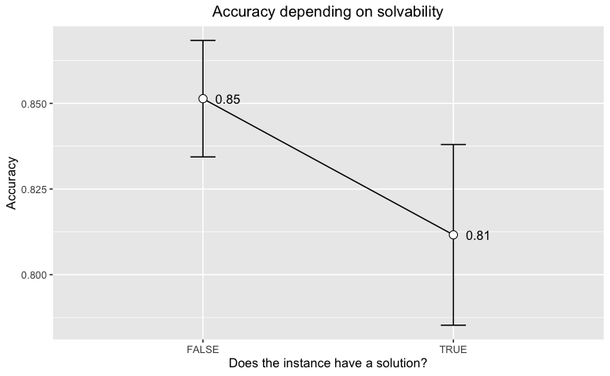

```r
dataInput=dataDecProp %>% group_by(sol,pID)%>%summarise(accuracy1=mean(correct))%>%ungroup()%>%group_by(sol)%>%summarise(accuracy=mean(accuracy1),se=se(accuracy1))%>%ungroup()
plo = ggplot(data=dataInput, aes(y=accuracy, x=as.factor(as.logical(sol)), label = round(accuracy,digits = 2),group=1)) +
  geom_line()+
  geom_errorbar(aes(ymin=accuracy-se, ymax=accuracy+se), width=.1) +
  geom_point(shape=21, size=3, fill="white")+
  labs(title="Accuracy depending on solvability",x="Does the instance have a solution?",y="Accuracy")+
  theme(plot.title = element_text(hjust = 0.5), axis.text.x = element_text(angle=0,hjust=0.5))+
  geom_text(hjust=-0.5, colour="black")

outputName = "app02g"
plotExport(plo,outputName)
```

```r
anovaModel=aov(correct~sol+Error(pID/sol),dataDecProp)
anovaPValue=summary(anovaModel)[[2]][[1]][['Pr(>F)']][[1]]
print(paste("P-value for one way ANOVA:",signif(anovaPValue,digits=3)))
```

[1] “P-value for one way ANOVA: 0.163”

```r
rm(dataInput)
```

```r
#logistic with random effects (intercept)
logitRandomIntercept = glmer(correct ~ answer + (1|pID), family=binomial(link="logit"), data=dataDecProp)

title="Logistic regressions"
tableName='app02r'
modelTableStyle(logitRandomIntercept,title,outputType,tableName)
```

[1] “app02r” length of NULL cannot be changedlength of NULL cannot be changedlength of NULL cannot be changedlength of NULL cannot be changedlength of NULL cannot be changed

|  | Logistic regressions |
| --- | --- |
|  | correct |
|  | Random Intercept |
| answer | 0.168 |
|  | (0.144) |
|  | p = 0.245 |
| Constant | 1.565*** |
|  | (0.131) |
|  | p = 0.000 |
| Observations | 1,427 |
| Log Likelihood | -639.750 |
| Akaike Inf. Crit. | 1,285.500 |
| Bayesian Inf. Crit. | 1,301.290 |
| *Note:* | p<0.1; p<0.05; p<0.01 |

## 1.7 Instance Sampling Figure

```
[1] "decSampling"
[1] "/Volumes/GoogleDrive/My Drive/Melbourne/UNIMELB/Research/Complexity Project/KS-IC/Code/Behavioural-Analysis/PNAS"
quartz_off_screen
                2
```

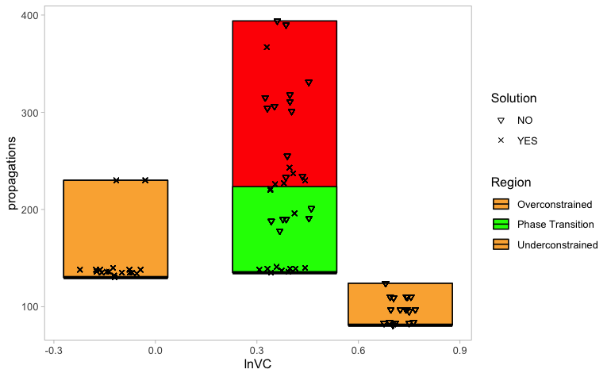

```r
#This shows the instances sampled for the decision task, together with the regions from which they were sampled
dataInput = dataDecProp
# dataInput$nCapacity=dataInput$c/dataInput$totalWeights
# dataInput$nProfit=dataInput$p /dataInput$totalValues

dataInput$lnVC=log(dataInput$nProfit/dataInput$nCapacity)
dataInput3 = dataInput %>% mutate(region=recode(type, `1`= 'Phase Transition',
                                                `2`= 'Phase Transition', `3`= 'Phase Transition',
                                                `4`='Phase Transition', '5'='Overconstrained',
                                                '6'='Underconstrained'))

dataInput2 =dataInput3 %>% group_by(region) %>% summarise(minP=min(propagations),
                                                       medianP = median(propagations),
                                                       maxP =max(propagations),
                                                       mlnVC=mean(lnVC)) %>% arrange(desc(region))
phaseTransitionLevelLow=log(0.6/0.45)
phaseTransitionLevelHigh=log(0.65/0.4)
OUTphaseTransitionLevelLow=log(0.85/0.45)
OUTphaseTransitionLevelHigh=log(0.9/0.4)
OUT2phaseTransitionLevelLow=log(0.35/0.45)
OUT2phaseTransitionLevelHigh=log(0.4/0.4)

plo1 = ggplot(dataInput3,aes(x=lnVC,y=propagations,group=as.factor(region)))+
  geom_crossbar(data=dataInput2,aes(ymin = minP, ymax = maxP, x = mlnVC, y = minP),
                fill = "red",alpha=1)+
  geom_crossbar(data=dataInput2,aes(ymin = minP, ymax = c(maxP[1],medianP[2],maxP[3]), x = mlnVC, y = minP, fill=as.factor(region)),alpha=1)+
  scale_fill_manual(name  ="Region",
                     breaks=c("Overconstrained", "Phase Transition", "Underconstrained"),
                     labels=c("Overconstrained", "Phase Transition", "Underconstrained"),
                     values=c("#FBB040","green","#FBB040"))+
  geom_point(aes(shape=as.factor(sol)))+
  scale_shape_manual(name  ="Solution",
                        breaks=c("0", "1"),
                        labels=c("NO", "YES"),
                        values=c(6,4))+
  theme_light()+
  theme(panel.grid.major = element_blank(), panel.grid.minor = element_blank(),plot.title = element_text(hjust = 0.5))

plotExport(plo1,"decSampling")
```

# 2 Knapsack Optimisation Variant

```r
dataOptProp = read_csv(fileDataOpt)
dataOptTime = read_csv(fileDataOpt_time)
summaryListOpt= summaryData(dataOptProp)
```

## 2.1 Descriptive Sumamry

```r
print(paste('Participants To be analysed are:',paste(unique(dataOptProp$pID),collapse=" ")))
```

```
[1] "Participants To be analysed are: be30 be31 be32 be19 be15 be24 be26 be16 be25 be18 be33 be14 be29 be28 be17 be27 be23 be21 be22 be20"
```

```r
print(paste('Number of participants to analyse :',length(unique(dataOptProp$pID)) ) )
```

```
[1] "Number of participants to analyse : 20"
```

```r
print(paste("The overall Accuracy was: ",mean(dataOptProp$correct)))
```

```
[1] "The overall Accuracy was:  0.832402234636871"
```

```r
#Summary Stats for Optimisation Problem
dataInput=dataOptProp
dataInput2= dataOptTime

accuracySummary = dataInput %>% group_by(pID) %>% summarise(acc=mean(correct)) %>% summarise(mean=mean(acc),min=min(acc),max=max(acc),SD=sd(acc))
```

`summarise()` ungrouping output (override with `.groups` argument)

```r
kable(accuracySummary, digits=2, caption ="Accuracy Summary")
```

| mean | min | max | SD |
| --- | --- | --- | --- |
| 0.83 | 0.67 | 0.94 | 0.08 |

```r
timeSummary = dataInput2 %>% group_by(pID) %>% summarise(acc=mean(timeSpent)) %>% summarise(mean=mean(acc),min=min(acc),max=max(acc),SD=sd(acc))
```

`summarise()` ungrouping output (override with `.groups` argument)

```r
kable(timeSummary, digits=2, caption ="Time spent Summary")
```

| mean | min | max | SD |
| --- | --- | --- | --- |
| 42.51 | 27.38 | 58.66 | 8.09 |

### 2.1.1 Effect of Trial number

#### 2.1.1.1 Trial Number and Accuracy

```r
#Trial (experience effect) effect on accuracy
dataInput=dataOptProp
dataInput$totalTrial = dataInput$block * dataInput$trial

summaryByBlock = dataInput %>% group_by(block,pID) %>% summarise(acc=mean(correct)) %>% summarise(mean=mean(acc),min=min(acc),max=max(acc),SD=sd(acc))
```

`summarise()` regrouping output by ‘block’ (override with `.groups` argument) `summarise()` ungrouping output (override with `.groups` argument)

```r
kable(summaryByBlock, digits=2, caption="Accuracy By Block")
```

| block | mean | min | max | SD |
| --- | --- | --- | --- | --- |
| 1 | 0.79 | 0.44 | 1 | 0.14 |
| 2 | 0.88 | 0.67 | 1 | 0.11 |

```r
#Regression
logitRandomIntercept = glmer(correct ~ totalTrial+ (1|pID), family=binomial(link="logit"), data=dataInput)
```

boundary (singular) fit: see ?isSingular

```r
title="Logistic regressions"
tableName='opt01r'
modelTableStyle(logitRandomIntercept,title,outputType,tableName)
```

[1] “opt01r” length of NULL cannot be changedlength of NULL cannot be changedlength of NULL cannot be changedlength of NULL cannot be changedlength of NULL cannot be changed

|  | Logistic regressions |
| --- | --- |
|  | correct |
|  | Random Intercept |
| totalTrial | 0.012 |
|  | (0.030) |
|  | p = 0.683 |
| Constant | 1.512*** |
|  | (0.261) |
|  | p = 0.000 |
| Observations | 358 |
| Log Likelihood | -161.752 |
| Akaike Inf. Crit. | 329.504 |
| Bayesian Inf. Crit. | 341.146 |
| *Note:* | p<0.1; p<0.05; p<0.01 |

#### 2.1.1.2 Trial Number and Time Spent

```r
#Trial (experience effect) effect on timeSpent
dataInput=dataOptTime
dataInput$totalTrial = dataInput$block * dataInput$trial

summaryByBlock = dataInput %>% group_by(block,pID) %>% summarise(time=mean(timeSpent)) %>% summarise(mean=mean(time),min=min(time),max=max(time),SD=sd(time))
```

`summarise()` regrouping output by ‘block’ (override with `.groups` argument) `summarise()` ungrouping output (override with `.groups` argument)

```r
kable(summaryByBlock,digits=2 , caption="Time Spent per Trial segregated By Block")
```

| block | mean | min | max | SD |
| --- | --- | --- | --- | --- |
| 1 | 42.81 | 31.11 | 57.33 | 7.60 |
| 2 | 42.22 | 23.65 | 60.00 | 9.07 |

```r
#Regression
linearRandomIntercept = lmer(timeSpent ~ totalTrial+ (1|pID), data=dataInput)

title="Linear regressions"
tableName='opt02r'
modelTableStyle(linearRandomIntercept,title,outputType,tableName)
```

[1] “opt02r” length of NULL cannot be changedlength of NULL cannot be changedlength of NULL cannot be changedlength of NULL cannot be changedlength of NULL cannot be changed

|  | Linear regressions |
| --- | --- |
|  | timeSpent |
|  | Random Intercept |
| totalTrial | 0.095 |
|  | (0.135) |
|  | p = 0.483 |
| Constant | 41.802*** |
|  | (2.210) |
|  | p = 0.000 |
| Observations | 305 |
| Log Likelihood | -1,188.894 |
| Akaike Inf. Crit. | 2,385.788 |
| Bayesian Inf. Crit. | 2,400.670 |
| *Note:* | p<0.1; p<0.05; p<0.01 |

## 2.2 In and Out of Phase Transition Contrast

### 2.2.1 Phase Transition and Accuracy (Computational Performance)

```
[1] "opt03g"
[1] "/Volumes/GoogleDrive/My Drive/Melbourne/UNIMELB/Research/Complexity Project/KS-IC/Code/Behavioural-Analysis/PNAS"
quartz_off_screen
                2
```

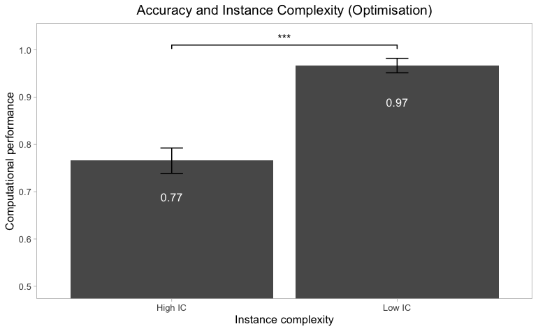

```r
dataInput=dataOptProp %>% group_by(phaseT,pID)%>%summarise(accuracy1=mean(correct))%>%ungroup()%>%group_by(phaseT)%>%summarise(accuracy=mean(accuracy1),se=se(accuracy1))%>%ungroup()
dataInput$phaseT = recode(dataInput$phaseT, '0' = "Low IC", '1' = "High IC")

plo= ggplot(data=dataInput, aes(y=accuracy, x=as.factor(phaseT),label = round(accuracy,digits = 2))) +
  geom_bar(stat = "identity")+
  geom_errorbar(aes(ymin=accuracy-se, ymax=accuracy+se), width=.1)+
  geom_signif(comparisons = list(c("Low IC","High IC")), annotations="***", y_position = 1.01, tip_length = 0.03)+
  labs(title="Accuracy and Instance Complexity (Optimisation)",x="Instance complexity",y="Computational performance")+
  coord_cartesian(ylim = c(0.5,1.03))+
  geom_text(hjust=0.5,vjust = 5, colour="white") +
  theme_light()+
  theme(panel.grid.major = element_blank(), panel.grid.minor = element_blank(),plot.title = element_text(hjust = 0.5))

outputName = "opt03g"
plotExport(plo,outputName)
```

```r
anovaModel=aov(correct~phaseT+Error(pID/phaseT),dataOptProp)
anovaPValue=summary(anovaModel)[[2]][[1]][['Pr(>F)']][[1]]
print(paste("P-value for one way ANOVA:",signif(anovaPValue,digits=3)))
```

```
[1] "P-value for one way ANOVA: 2.21e-06"
```

```r
rm(dataInput)
```

```r
#logistic with random effects (intercept)
logitRandomIntercept = glmer(correct ~ phaseT + (1|pID), family=binomial(link="logit"), data=dataOptProp)
```

boundary (singular) fit: see ?isSingular

```r
title="Logistic regressions"
tableName='opt03r'
modelTableStyle(logitRandomIntercept,title,outputType,tableName)
```

[1] “opt03r” length of NULL cannot be changedlength of NULL cannot be changedlength of NULL cannot be changedlength of NULL cannot be changedlength of NULL cannot be changed

|  | Logistic regressions |
| --- | --- |
|  | correct |
|  | Random Intercept |
| phaseT | -2.175*** |
|  | (0.531) |
|  | p = 0.00005 |
| Constant | 3.359*** |
|  | (0.509) |
|  | p = 0.000 |
| Observations | 358 |
| Log Likelihood | -147.622 |
| Akaike Inf. Crit. | 301.245 |
| Bayesian Inf. Crit. | 312.887 |
| *Note:* | p<0.1; p<0.05; p<0.01 |

### 2.2.2 Time Spent (*Effort*) In/Out Phase Transition

```
[1] "opt04g"
[1] "/Volumes/GoogleDrive/My Drive/Melbourne/UNIMELB/Research/Complexity Project/KS-IC/Code/Behavioural-Analysis/PNAS"
quartz_off_screen
                2
```

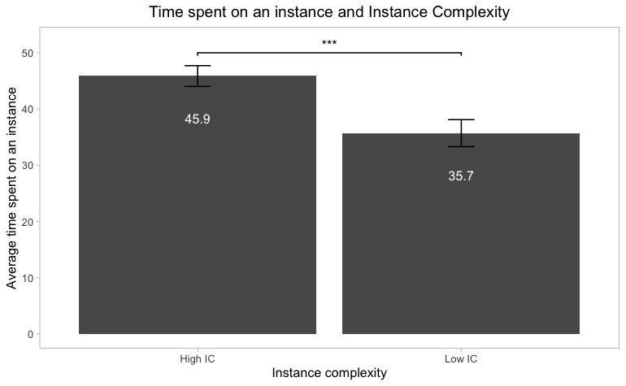

```r
dataInput=dataOptTime %>% group_by(phaseT,pID)%>%summarise(timeSpentMeans=mean(timeSpent))%>%ungroup()%>%group_by(phaseT)%>%summarise(time=mean(timeSpentMeans),se=se(timeSpentMeans))%>%ungroup()
dataInput$phaseT = recode(dataInput$phaseT, '0' = "Low IC", '1' = "High IC")

plo= ggplot(data=dataInput, aes(y=time, x=as.factor(phaseT),label = round(time,digits = 1))) +
  geom_bar(stat = "identity")+
  geom_errorbar(aes(ymin=time-se, ymax=time+se), width=.1)+
  geom_signif(comparisons = list(c("Low IC","High IC")), annotations="***", y_position = 50, tip_length = 0.03)+
  labs(title="Time spent on an instance and Instance Complexity",x="Instance complexity",y="Average time spent on an instance")+
  geom_text(hjust=0.5,vjust = 5, colour="white") +
  theme_light()+
  theme(panel.grid.major = element_blank(), panel.grid.minor = element_blank(),plot.title = element_text(hjust = 0.5))+
  coord_cartesian(ylim = c(0,52))

outputName = "opt04g"
plotExport(plo,outputName)
```

```r
#Stats test for time in and out of phase transition: ANOVA
anovaModel=aov(timeSpent~phaseT+Error(pID/phaseT),dataOptTime)
anovaPValue=summary(anovaModel)[[2]][[1]][['Pr(>F)']][[1]]
print(paste("P-value for one way ANOVA:",signif(anovaPValue,digits=3)))
```

```
[1] "P-value for one way ANOVA: 3.39e-07"
```

```r
rm(dataInput)
```

```r
#logistic with random effects (intercept)
linearMRandomIntercept = lmer(timeSpent ~ phaseT + (1|pID), data=dataOptTime)

title="Linear regressions"
tableName='opt04r'
modelTableStyle(linearMRandomIntercept,title,outputType,tableName)
```

[1] “opt04r” length of NULL cannot be changedlength of NULL cannot be changedlength of NULL cannot be changedlength of NULL cannot be changedlength of NULL cannot be changed

|  | Linear regressions |
| --- | --- |
|  | timeSpent |
|  | Random Intercept |
| phaseT | 10.114*** |
|  | (1.236) |
|  | p = 0.000 |
| Constant | 35.749*** |
|  | (2.132) |
|  | p = 0.000 |
| Observations | 305 |
| Log Likelihood | -1,156.717 |
| Akaike Inf. Crit. | 2,321.433 |
| Bayesian Inf. Crit. | 2,336.314 |
| *Note:* | p<0.1; p<0.05; p<0.01 |

### 2.2.3 Effort and Phase Transition interaction effect on Accuracy

##### 2.2.3.0.1 Is the effect of effort (time spent) on accuracy (Computational Performance) modulated by Instance Complexity (In/Out of Phase Transition)?

```r
logitRandomIntercept = glmer(correct ~ scale(timeSpent) + phaseT +  phaseT:scale(timeSpent) + (1|pID), family=binomial(link="logit"), data=dataOptTime)

title="Logistic regressions"
tableName='opt05r'
modelTableStyle(logitRandomIntercept,title,outputType,tableName)
```

[1] “opt05r” length of NULL cannot be changedlength of NULL cannot be changedlength of NULL cannot be changedlength of NULL cannot be changedlength of NULL cannot be changed

|  | Logistic regressions |
| --- | --- |
|  | correct |
|  | Random Intercept |
| scale(timeSpent) | -0.089 |
|  | (0.735) |
|  | p = 0.905 |
| phaseT | -2.420*** |
|  | (0.817) |
|  | p = 0.004 |
| scale(timeSpent):phaseT | -0.709 |
|  | (0.760) |
|  | p = 0.352 |
| Constant | 3.914*** |
|  | (0.796) |
|  | p = 0.00000 |
| Observations | 305 |
| Log Likelihood | -115.185 |
| Akaike Inf. Crit. | 240.369 |
| Bayesian Inf. Crit. | 258.971 |
| *Note:* | p<0.1; p<0.05; p<0.01 |

## 2.3 MZN Propagations

### 2.3.1 MZN Propagations and Accuracy (Computational Performance)

```
[1] "opt06g"
[1] "/Volumes/GoogleDrive/My Drive/Melbourne/UNIMELB/Research/Complexity Project/KS-IC/Code/Behavioural-Analysis/PNAS"
quartz_off_screen
                2
```

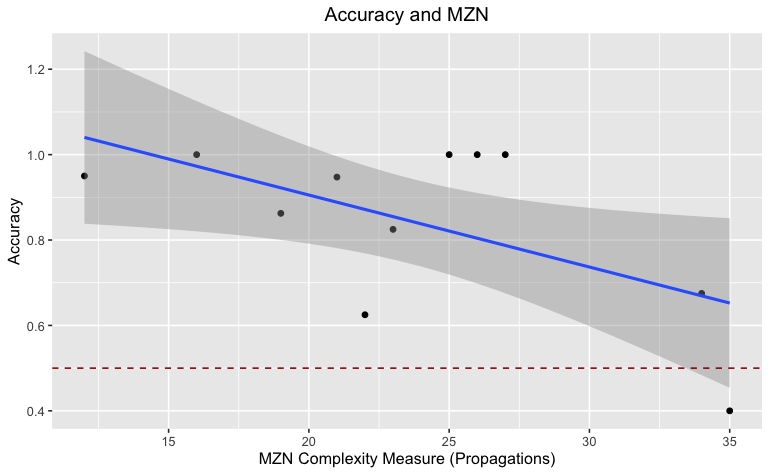

```r
#MZN Propagations
groups4=dataOptProp %>% group_by(propagations)
dat4=summarise(groups4, accuracy=mean(correct), se=se(correct))
plo = ggplot(data=dat4, aes(y=accuracy, x=propagations)) +
  geom_point()+
  labs(title="Accuracy and MZN",y="Accuracy",x="MZN Complexity Measure (Propagations)")+
  theme(plot.title = element_text(hjust = 0.5)) +
  stat_smooth(method = glm)+
  geom_hline(aes(yintercept=0.5), colour="#990000", linetype="dashed")

outputName = "opt06g"
plotExport(plo,outputName)
```

```r
logitRandomIntercept = glmer(correct ~ propagations + (1|pID), family=binomial(link="logit"), data=dataOptProp)
```

boundary (singular) fit: see ?isSingular

```r
#summary(logitRandomInterceptSlope)

title="Logistic regressions"
tableName='opt06r'
modelTableStyle(logitRandomIntercept,title,outputType,tableName)
```

[1] “opt06r” length of NULL cannot be changedlength of NULL cannot be changedlength of NULL cannot be changedlength of NULL cannot be changedlength of NULL cannot be changed

|  | Logistic regressions |
| --- | --- |
|  | correct |
|  | Random Intercept |
| propagations | -0.108*** |
|  | (0.022) |
|  | p = 0.00001 |
| Constant | 4.230*** |
|  | (0.593) |
|  | p = 0.000 |
| Observations | 358 |
| Log Likelihood | -149.815 |
| Akaike Inf. Crit. | 305.630 |
| Bayesian Inf. Crit. | 317.272 |
| *Note:* | p<0.1; p<0.05; p<0.01 |

### 2.3.2 MZN Propagations and Time Spent

```
[1] "opt06g2"
[1] "/Volumes/GoogleDrive/My Drive/Melbourne/UNIMELB/Research/Complexity Project/KS-IC/Code/Behavioural-Analysis/PNAS"
quartz_off_screen
                2
```

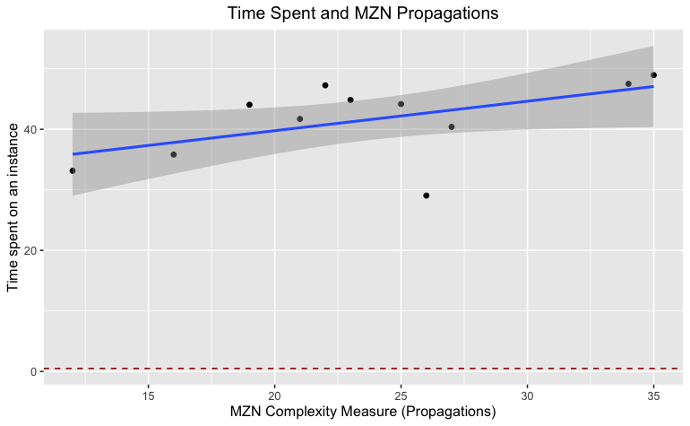

```r
#Average per propagations plotted
groups5=dataOptTime %>% group_by(propagations)
dat5=summarise(groups5, time=mean(timeSpent), se=se(propagations))
plo = ggplot(data=dat5, aes(y=time, x=propagations)) +
  geom_point()+
  labs(title="Time Spent and MZN Propagations",y="Time spent on an instance",x="MZN Complexity Measure (Propagations)")+
  theme(plot.title = element_text(hjust = 0.5)) +
  stat_smooth(method = glm)+
  geom_hline(aes(yintercept=0.5), colour="#990000", linetype="dashed")

outputName = "opt06g2"
plotExport(plo,outputName)
```

```r
linearMRandomIntercept = lmer(timeSpent ~ propagations + (1|pID), data=dataOptTime)

title="Linear regressions"
tableName='opt06r2'
modelTableStyle(linearMRandomIntercept,title,outputType,tableName)
```

[1] “opt06r2” length of NULL cannot be changedlength of NULL cannot be changedlength of NULL cannot be changedlength of NULL cannot be changedlength of NULL cannot be changed

|  | Linear regressions |
| --- | --- |
|  | timeSpent |
|  | Random Intercept |
| propagations | 0.438*** |
|  | (0.100) |
|  | p = 0.00002 |
| Constant | 32.505*** |
|  | (3.013) |
|  | p = 0.000 |
| Observations | 305 |
| Log Likelihood | -1,180.119 |
| Akaike Inf. Crit. | 2,368.238 |
| Bayesian Inf. Crit. | 2,383.119 |
| *Note:* | p<0.1; p<0.05; p<0.01 |

### 2.3.3 MZN Propagations: Controlling for propagations does effort still has a significant effect on accuracy

```r
logitRandomIntercept = glmer(correct ~ propagations + timeSpent + (1|pID), family=binomial(link="logit"), data=dataOptTime)
#summary(logitRandomInterceptSlope)

title="Logistic regressions"
tableName='opt06r3'
modelTableStyle(logitRandomIntercept,title,outputType,tableName)
```

[1] “opt06r3” length of NULL cannot be changedlength of NULL cannot be changedlength of NULL cannot be changedlength of NULL cannot be changedlength of NULL cannot be changed

|  | Logistic regressions |
| --- | --- |
|  | correct |
|  | Random Intercept |
| propagations | -0.111*** |
|  | (0.026) |
|  | p = 0.00003 |
| timeSpent | -0.068*** |
|  | (0.018) |
|  | p = 0.0002 |
| Constant | 7.517*** |
|  | (1.164) |
|  | p = 0.000 |
| Observations | 305 |
| Log Likelihood | -115.439 |
| Akaike Inf. Crit. | 238.878 |
| Bayesian Inf. Crit. | 253.759 |
| *Note:* | p<0.1; p<0.05; p<0.01 |

## 2.4 SAT Decisions

### 2.4.1 SAT and Accuracy (Computational Performance)

```
[1] "opt07g"
[1] "/Volumes/GoogleDrive/My Drive/Melbourne/UNIMELB/Research/Complexity Project/KS-IC/Code/Behavioural-Analysis/PNAS"
quartz_off_screen
                2
```

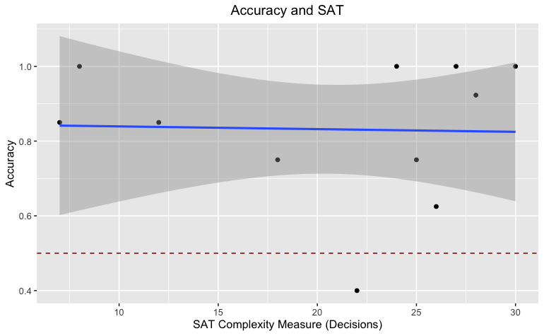

```r
#SAT Decisions
groups5=dataOptProp %>% group_by(decisions)
dat5=summarise(groups5, accuracy=mean(correct), se=se(correct))
plo = ggplot(data=dat5, aes(y=accuracy, x=decisions)) +
  geom_point()+
  labs(title="Accuracy and SAT",y="Accuracy",x="SAT Complexity Measure (Decisions)")+
  theme(plot.title = element_text(hjust = 0.5)) +
  stat_smooth(method = glm)+
  geom_hline(aes(yintercept=0.5), colour="#990000", linetype="dashed")

outputName = "opt07g"
plotExport(plo,outputName)
```

```r
logitRandomIntercept = glmer(correct ~ decisions + (1|pID), family=binomial(link="logit"), data=dataOptProp)
```

boundary (singular) fit: see ?isSingular

```r
title="Logistic regressions"
tableName='opt07r'
modelTableStyle(logitRandomIntercept,title,outputType,tableName)
```

[1] “opt07r” length of NULL cannot be changedlength of NULL cannot be changedlength of NULL cannot be changedlength of NULL cannot be changedlength of NULL cannot be changed

|  | Logistic regressions |
| --- | --- |
|  | correct |
|  | Random Intercept |
| decisions | -0.026 |
|  | (0.018) |
|  | p = 0.157 |
| Constant | 2.124*** |
|  | (0.404) |
|  | p = 0.00000 |
| Observations | 358 |
| Log Likelihood | -160.808 |
| Akaike Inf. Crit. | 327.615 |
| Bayesian Inf. Crit. | 339.257 |
| *Note:* | p<0.1; p<0.05; p<0.01 |

### 2.4.2 SAT Decisions and Time Spent

```
[1] "opt08g"
[1] "/Volumes/GoogleDrive/My Drive/Melbourne/UNIMELB/Research/Complexity Project/KS-IC/Code/Behavioural-Analysis/PNAS"
quartz_off_screen
                2
```

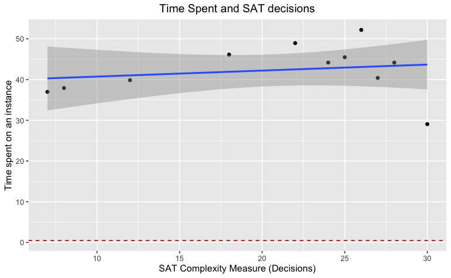

```r
groups5=dataOptTime %>% group_by(decisions)
dat5=summarise(groups5, time=mean(timeSpent), se=se(decisions))
plo = ggplot(data=dat5, aes(y=time, x=decisions)) +
  geom_point()+
  labs(title="Time Spent and SAT decisions",y="Time spent on an instance",x="SAT Complexity Measure (Decisions)")+
  theme(plot.title = element_text(hjust = 0.5)) +
  stat_smooth(method = glm)+
  geom_hline(aes(yintercept=0.5), colour="#990000", linetype="dashed")

outputName = "opt08g"
plotExport(plo,outputName)
```

```r
linearMRandomIntercept = lmer(timeSpent ~ decisions + (1|pID), data=dataOptTime)

title="Linear regressions"
tableName='opt08r'
modelTableStyle(linearMRandomIntercept,title,outputType,tableName)
```

[1] “opt08r” length of NULL cannot be changedlength of NULL cannot be changedlength of NULL cannot be changedlength of NULL cannot be changedlength of NULL cannot be changed

|  | Linear regressions |
| --- | --- |
|  | timeSpent |
|  | Random Intercept |
| decisions | 0.276*** |
|  | (0.080) |
|  | p = 0.001 |
| Constant | 37.165*** |
|  | (2.503) |
|  | p = 0.000 |
| Observations | 305 |
| Log Likelihood | -1,183.824 |
| Akaike Inf. Crit. | 2,375.647 |
| Bayesian Inf. Crit. | 2,390.529 |
| *Note:* | p<0.1; p<0.05; p<0.01 |

## 2.5 Sahni-K Analysis

### 2.5.1 Sahni-K and Accuracy (Computational Performance)

```
[1] "opt09g"
[1] "/Volumes/GoogleDrive/My Drive/Melbourne/UNIMELB/Research/Complexity Project/KS-IC/Code/Behavioural-Analysis/PNAS"
quartz_off_screen
                2
```

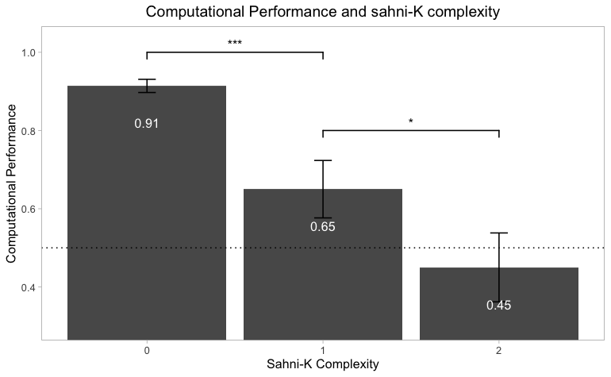

```r
dataInput=dataOptProp %>% group_by(sahniK,pID)%>%summarise(accuracy1=mean(correct))%>%ungroup()%>%group_by(sahniK)%>%summarise(accuracy=mean(accuracy1),se=se(accuracy1))%>%ungroup()
plo= ggplot(data=dataInput, aes(y=accuracy, x=as.factor(sahniK),
                                label = round(accuracy,digits = 2))) +
  geom_bar(stat = "identity")+
  geom_errorbar(aes(ymin=accuracy-se, ymax=accuracy+se), width=.1)+
  geom_signif(comparisons = list(c("0","1")), annotations="***",
             y_position = 1, tip_length = 0.03)+
  geom_signif(comparisons = list(c("1","2")), annotations="*",
               y_position = 0.8, tip_length = 0.03)+
  labs(title="Computational Performance and sahni-K complexity",
       x="Sahni-K Complexity",y="Computational Performance")+
  coord_cartesian(ylim = c(0.3,1.03))+
  geom_text(hjust=0.5,vjust = 4.5, colour="white") +
  theme_light()+
  theme(panel.grid.major = element_blank(), panel.grid.minor = element_blank(),plot.title = element_text(hjust = 0.5))+
  geom_hline(aes(yintercept = 0.5),linetype="dotted")

outputName = "opt09g"
plotExport(plo,outputName)
```

```r
#Sahni-K boxplot: I think it says quite a bit
# dataInput=dataOptProp %>% group_by(sahniK,pID)%>%summarise(accuracy=mean(correct))%>%ungroup()
#
# ggplot(dataInput, aes(x=as.factor(sahniK), y=accuracy))+
#   geom_boxplot(outlier.shape=1)+
#   #geom_boxplot( aes(x=as.logical(phaseT), y=accuracy),outlier.shape=1) +
#   stat_summary(fun.y=mean, colour="darkred", geom="point", size=2, shape=17) +
#   stat_summary(fun.y=mean, colour="darkred", geom="text", size=3, aes( label=round(..y.., digits=2)),hjust=1.5,vjust=0.5) +
#   #coord_cartesian(ylim = c(0,1)) +
#   labs(title="Accuracy and Sahni-K",x="Sahni-K",y="Percentage")+
#   theme(plot.title = element_text(hjust = 0.5))+#, axis.text.x = element_text(angle=45,hjust=1))+
#   geom_hline(aes(yintercept=0.5), colour="#990000", linetype="dashed")
```

```r
logitRandomIntercept = glmer(correct ~ sahniK + (1|pID), family=binomial(link="logit"), data=dataOptProp)

title="Logistic regressions"
tableName='opt09r'
modelTableStyle(logitRandomIntercept,title,outputType,tableName)
```

[1] “opt09r” length of NULL cannot be changedlength of NULL cannot be changedlength of NULL cannot be changedlength of NULL cannot be changedlength of NULL cannot be changed

|  | Logistic regressions |
| --- | --- |
|  | correct |
|  | Random Intercept |
| sahniK | -1.333*** |
|  | (0.193) |
|  | p = 0.000 |
| Constant | 2.310*** |
|  | (0.219) |
|  | p = 0.000 |
| Observations | 358 |
| Log Likelihood | -135.816 |
| Akaike Inf. Crit. | 277.633 |
| Bayesian Inf. Crit. | 289.274 |
| *Note:* | p<0.1; p<0.05; p<0.01 |

```r
#logistic corroborations of significance shown in Accuracy/SahniK plot
dataInput =dataOptProp
dataInput$sahniK0= (dataInput$sahniK==0)
dataInput$sahniK1= (dataInput$sahniK==1)
dataInput$sahniK2= (dataInput$sahniK==2)

#logitRandomIntercept0 = glmer(correct ~ sahniK1 + sahniK2 + (1|pID), family=binomial(link="logit"), data=dataInput)

logitRandomIntercept1 = glmer(correct ~ sahniK0 + sahniK2 + (1|pID), family=binomial(link="logit"), data=dataInput)

title="Logistic regressions"
tableName='opt09r1'
modelTableStyle(logitRandomIntercept1,title,outputType,tableName)
```

[1] “opt09r1” length of NULL cannot be changedlength of NULL cannot be changedlength of NULL cannot be changedlength of NULL cannot be changedlength of NULL cannot be changed

|  | Logistic regressions |
| --- | --- |
|  | correct |
|  | Random Intercept |
| sahniK0 | 1.751*** |
|  | (0.398) |
|  | p = 0.00002 |
| sahniK2 | -0.828* |
|  | (0.463) |
|  | p = 0.074 |
| Constant | 0.625* |
|  | (0.337) |
|  | p = 0.064 |
| Observations | 358 |
| Log Likelihood | -135.116 |
| Akaike Inf. Crit. | 278.233 |
| Bayesian Inf. Crit. | 293.755 |
| *Note:* | p<0.1; p<0.05; p<0.01 |

### 2.5.2 Sahni-K and Time Spent

```
[1] "opt10g"
[1] "/Volumes/GoogleDrive/My Drive/Melbourne/UNIMELB/Research/Complexity Project/KS-IC/Code/Behavioural-Analysis/PNAS"
quartz_off_screen
                2
```

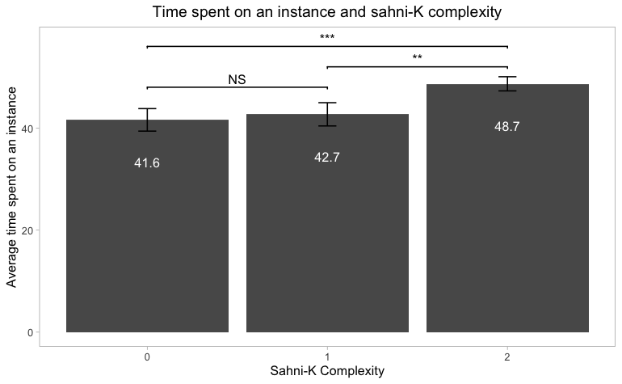

```r
dataInput=dataOptTime %>% group_by(sahniK,pID)%>%summarise(timeSpentMeans=mean(timeSpent))%>%ungroup()%>%group_by(sahniK)%>%summarise(time=mean(timeSpentMeans),se=se(timeSpentMeans))%>%ungroup()
plo= ggplot(data=dataInput, aes(y=time, x=as.factor(sahniK),
                                label = round(time,digits = 1))) +
  geom_bar(stat = "identity")+
  geom_errorbar(aes(ymin=time-se, ymax=time+se), width=.1)+
  geom_signif(comparisons = list(c("1","2")), annotations="**",
               y_position = 52, tip_length = 0.03)+
 geom_signif(comparisons = list(c("0","2")), annotations="***",
             y_position = 56, tip_length = 0.03)+
 geom_signif(comparisons = list(c("0","1")), annotations="NS",
             y_position = 48, tip_length = 0.03)+
  labs(title="Time spent on an instance and sahni-K complexity",
       x="Sahni-K Complexity",y="Average time spent on an instance")+
  coord_cartesian(ylim = c(0,57))+
  geom_text(hjust=0.5,vjust = 5, colour="white") +
  theme_light()+
  theme(panel.grid.major = element_blank(), panel.grid.minor = element_blank(),plot.title = element_text(hjust = 0.5))

outputName = "opt10g"
plotExport(plo,outputName)
```

```r
linearMRandomIntercept = lmer(timeSpent ~ sahniK + (1|pID), data=dataOptTime)

title="Linear regressions"
tableName='opt10r'
modelTableStyle(linearMRandomIntercept,title,outputType,tableName)
```

[1] “opt10r” length of NULL cannot be changedlength of NULL cannot be changedlength of NULL cannot be changedlength of NULL cannot be changedlength of NULL cannot be changed

|  | Linear regressions |
| --- | --- |
|  | timeSpent |
|  | Random Intercept |
| sahniK | 3.125*** |
|  | (0.950) |
|  | p = 0.001 |
| Constant | 41.469*** |
|  | (1.990) |
|  | p = 0.000 |
| Observations | 305 |
| Log Likelihood | -1,181.856 |
| Akaike Inf. Crit. | 2,371.712 |
| Bayesian Inf. Crit. | 2,386.593 |
| *Note:* | p<0.1; p<0.05; p<0.01 |

```r
#logistic corroborations of significance shown in Accuracy/SahniK plot for time
dataInput =dataOptProp
dataInput$sahniK0= (dataInput$sahniK==0)
dataInput$sahniK1= (dataInput$sahniK==1)
dataInput$sahniK2= (dataInput$sahniK==2)

linearRandomIntercept0 = lmer(timeSpent ~ sahniK1 + sahniK2 + (1|pID), data=dataInput)

linearRandomIntercept1 = lmer(timeSpent ~ sahniK0 + sahniK2 + (1|pID), data=dataInput)

title="Linear regressions"
tableName='opt09r2a'
modelTableStyle(list(linearRandomIntercept0,linearRandomIntercept0),title,outputType,tableName)
```

[1] “opt09r2a” length of NULL cannot be changedlength of NULL cannot be changedlength of NULL cannot be changedlength of NULL cannot be changedlength of NULL cannot be changed

|  | Linear regressions |  |
| --- | --- | --- |
|  | timeSpent |  |
|  | Random Intercept |  |
|  | (1) | (2) |
| sahniK1 | 0.928 | 0.928 |
|  | (1.732) | (1.732) |
|  | p = 0.593 | p = 0.593 |
| sahniK2 | 6.011*** | 6.011*** |
|  | (1.732) | (1.732) |
|  | p = 0.001 | p = 0.001 |
| Constant | 44.360*** | 44.360*** |
|  | (2.212) | (2.212) |
|  | p = 0.000 | p = 0.000 |
| Observations | 358 | 358 |
| Log Likelihood | -1,362.686 | -1,362.686 |
| Akaike Inf. Crit. | 2,735.371 | 2,735.371 |
| Bayesian Inf. Crit. | 2,754.774 | 2,754.774 |
| *Note:* | p<0.1; p<0.05; p<0.01 |  |

```r
tableName='opt09r2b'
modelTableStyle(list(linearRandomIntercept1,linearRandomIntercept1),title,outputType,tableName)
```

[1] “opt09r2b” length of NULL cannot be changedlength of NULL cannot be changedlength of NULL cannot be changedlength of NULL cannot be changedlength of NULL cannot be changed

|  | Linear regressions |  |
| --- | --- | --- |
|  | timeSpent |  |
|  | Random Intercept |  |
|  | (1) | (2) |
| sahniK0 | -0.928 | -0.928 |
|  | (1.732) | (1.732) |
|  | p = 0.593 | p = 0.593 |
| sahniK2 | 5.084** | 5.084** |
|  | (2.290) | (2.290) |
|  | p = 0.027 | p = 0.027 |
| Constant | 45.288*** | 45.288*** |
|  | (2.672) | (2.672) |
|  | p = 0.000 | p = 0.000 |
| Observations | 358 | 358 |
| Log Likelihood | -1,362.686 | -1,362.686 |
| Akaike Inf. Crit. | 2,735.371 | 2,735.371 |
| Bayesian Inf. Crit. | 2,754.774 | 2,754.774 |
| *Note:* | p<0.1; p<0.05; p<0.01 |  |

### 2.5.3 Sahni-K, IC and Effort

##### 2.5.3.0.1 Is effort (time spent) modulated by Sahni-K or IC?

```r
linearRandomIntercept = lmer(timeSpent ~ sahniK + phaseT + sahniK:phaseT + (1|pID), data=dataOptTime)

title="Linear regressions"
tableName='opt11r'
modelTableStyle(linearRandomIntercept,title,outputType,tableName)
```

[1] “opt11r” length of NULL cannot be changedlength of NULL cannot be changedlength of NULL cannot be changedlength of NULL cannot be changedlength of NULL cannot be changed

|  | Linear regressions |
| --- | --- |
|  | timeSpent |
|  | Random Intercept |
| sahniK | 1.489 |
|  | (2.687) |
|  | p = 0.580 |
| phaseT | 9.535*** |
|  | (1.366) |
|  | p = 0.000 |
| sahniK:phaseT | 0.502 |
|  | (2.844) |
|  | p = 0.861 |
| Constant | 35.498*** |
|  | (2.178) |
|  | p = 0.000 |
| Observations | 305 |
| Log Likelihood | -1,151.532 |
| Akaike Inf. Crit. | 2,315.065 |
| Bayesian Inf. Crit. | 2,337.386 |
| *Note:* | p<0.1; p<0.05; p<0.01 |

## 2.6 Other Performance Measures

### 2.6.1 Profit Reached (Value Performance)

#### 2.6.1.1 Phase Transition and Value Performance

```
[1] "opt11Ag"
[1] "/Volumes/GoogleDrive/My Drive/Melbourne/UNIMELB/Research/Complexity Project/KS-IC/Code/Behavioural-Analysis/PNAS"
quartz_off_screen
                2
```

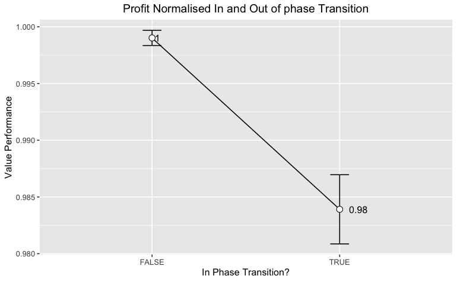

```r
dataInput=dataOptProp
dataInput=dataInput[dataInput$capacitySel<=dataInput$capacity,]
dataInput$profitNormalised=dataInput$profitSel/dataInput$profitOpt

dataInput2=dataInput %>% group_by(phaseT,pID)%>%summarise(profitNormalised1=mean(profitNormalised))%>%ungroup()%>%group_by(phaseT)%>%summarise(profitNormalised=mean(profitNormalised1),se=se(profitNormalised1))%>%ungroup()
plo = ggplot(data=dataInput2, aes(y=profitNormalised, x=as.factor(as.logical(phaseT)), label = round(profitNormalised,digits = 2),group=1)) +
  geom_line()+
  geom_errorbar(aes(ymin=profitNormalised-se, ymax=profitNormalised+se), width=.1) +
  geom_point(shape=21, size=3, fill="white")+
  labs(title="Profit Normalised In and Out of phase Transition",x="In Phase Transition?",y="Value Performance")+
  theme(plot.title = element_text(hjust = 0.5), axis.text.x = element_text(angle=0,hjust=0.5))+
  geom_text(hjust=-0.5, colour="black")
  #coord_cartesian(ylim = c(0,1))

outputName = "opt11Ag"
plotExport(plo,outputName)
```

```r
#Effect of phase Transition in Value (economic) performance
dataInput=dataInput

linearRandomIntercept = lmer(profitNormalised ~ phaseT + (1|pID), data=dataInput)

title="Linear regressions"
tableName='opt11Ar'
modelTableStyle(linearRandomIntercept,title,outputType,tableName)
```

[1] “opt11Ar” length of NULL cannot be changedlength of NULL cannot be changedlength of NULL cannot be changedlength of NULL cannot be changedlength of NULL cannot be changed

|  | Linear regressions |
| --- | --- |
|  | profitNormalised |
|  | Random Intercept |
| phaseT | -0.015*** |
|  | (0.004) |
|  | p = 0.00005 |
| Constant | 0.999*** |
|  | (0.003) |
|  | p = 0.000 |
| Observations | 347 |
| Log Likelihood | 685.782 |
| Akaike Inf. Crit. | -1,363.564 |
| Bayesian Inf. Crit. | -1,348.166 |
| *Note:* | p<0.1; p<0.05; p<0.01 |

#### 2.6.1.2 Time Spent and value performance

```
[1] "opt12g"
[1] "/Volumes/GoogleDrive/My Drive/Melbourne/UNIMELB/Research/Complexity Project/KS-IC/Code/Behavioural-Analysis/PNAS"
quartz_off_screen
                2
```

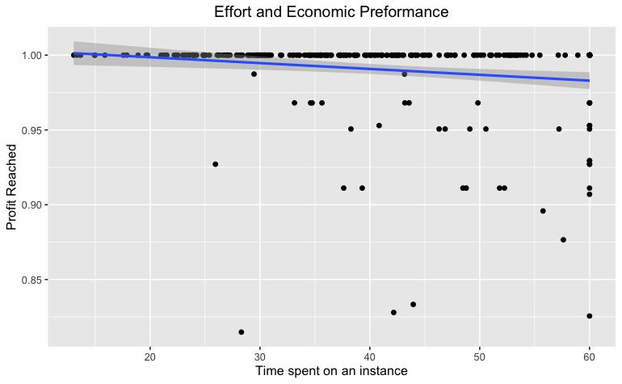

```r
dataTemp=dataOptTime
dataTemp=dataTemp[dataTemp$capacitySel<dataTemp$capacity,]
dataTemp$profitNormalised=dataTemp$profitSel/dataTemp$profitOpt

plo = ggplot(data=dataTemp, aes(x=timeSpent, y=profitNormalised)) +
  geom_point()+
  labs(title="Effort and Economic Preformance",x="Time spent on an instance",y="Profit Reached")+
  theme(plot.title = element_text(hjust = 0.5)) +
  stat_smooth(method = glm)

outputName = "opt12g"
plotExport(plo,outputName)
```

```r
cor.test(dataTemp$timeSpent,dataTemp$profitNormalised)
```

```
    Pearson's product-moment correlation

data:  dataTemp$timeSpent and dataTemp$profitNormalised
t = -3.0554, df = 284, p-value = 0.002461
alternative hypothesis: true correlation is not equal to 0
95 percent confidence interval:
 -0.28841337 -0.06373278
sample estimates:
       cor
-0.1783975
```

```r
linearMRandomIntercept = lmer(profitNormalised ~ timeSpent + (1|pID), data=dataTemp)

title="Linear regressions"
tableName='opt12r'
modelTableStyle(linearMRandomIntercept,title,outputType,tableName)
```

[1] “opt12r” length of NULL cannot be changedlength of NULL cannot be changedlength of NULL cannot be changedlength of NULL cannot be changedlength of NULL cannot be changed

|  | Linear regressions |
| --- | --- |
|  | profitNormalised |
|  | Random Intercept |
| timeSpent | -0.0005*** |
|  | (0.0001) |
|  | p = 0.001 |
| Constant | 1.009*** |
|  | (0.006) |
|  | p = 0.000 |
| Observations | 286 |
| Log Likelihood | 596.883 |
| Akaike Inf. Crit. | -1,185.765 |
| Bayesian Inf. Crit. | -1,171.141 |
| *Note:* | p<0.1; p<0.05; p<0.01 |

### 2.6.2 Item Performance (Number of clicks away from the optimum)

#### 2.6.2.1 Phase Transition and item Performance

```
[1] "opt13g"
[1] "/Volumes/GoogleDrive/My Drive/Melbourne/UNIMELB/Research/Complexity Project/KS-IC/Code/Behavioural-Analysis/PNAS"
quartz_off_screen
                2
```

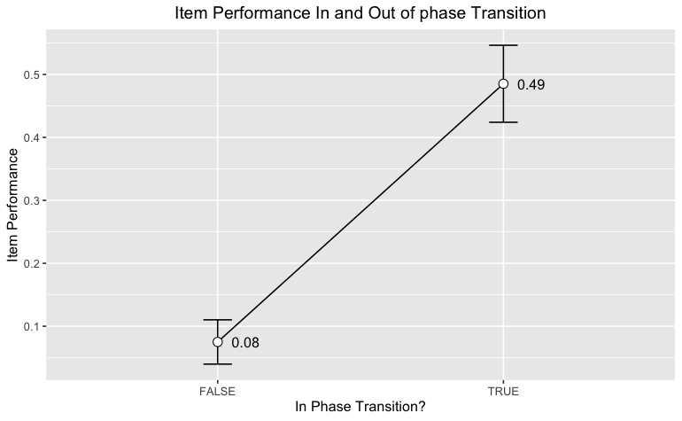

```r
dataInput=dataOptProp

dataInput2=dataInput %>% group_by(phaseT,pID)%>%summarise(meanDistance1=mean(itemDistanceFromOpt))%>%ungroup()%>%group_by(phaseT)%>%summarise(meanDistance=mean(meanDistance1),se=se(meanDistance1))%>%ungroup()
plo = ggplot(data=dataInput2, aes(y=meanDistance, x=as.factor(as.logical(phaseT)), label = round(meanDistance,digits = 2),group=1)) +
  geom_line()+
  geom_errorbar(aes(ymin=meanDistance-se, ymax=meanDistance+se), width=.1) +
  geom_point(shape=21, size=3, fill="white")+
  labs(title="Item Performance In and Out of phase Transition",x="In Phase Transition?",y="Item Performance")+
  theme(plot.title = element_text(hjust = 0.5), axis.text.x = element_text(angle=0,hjust=0.5))+
  geom_text(hjust=-0.5, colour="black")

outputName = "opt13g"
plotExport(plo,outputName)
```

```r
#Trial (experience effect) effect on timeSpent
dataInput=dataOptProp

linearRandomIntercept = lmer(itemDistanceFromOpt ~ phaseT + (1|pID), data=dataInput)

title="Linear regressions"
tableName='opt13r'
modelTableStyle(linearRandomIntercept,title,outputType,tableName)
```

[1] “opt13r” length of NULL cannot be changedlength of NULL cannot be changedlength of NULL cannot be changedlength of NULL cannot be changedlength of NULL cannot be changed

|  | Linear regressions |
| --- | --- |
|  | itemDistanceFromOpt |
|  | Random Intercept |
| phaseT | 0.410*** |
|  | (0.092) |
|  | p = 0.00001 |
| Constant | 0.076 |
|  | (0.076) |
|  | p = 0.319 |
| Observations | 358 |
| Log Likelihood | -441.574 |
| Akaike Inf. Crit. | 891.147 |
| Bayesian Inf. Crit. | 906.669 |
| *Note:* | p<0.1; p<0.05; p<0.01 |

#### 2.6.2.2 Time Spent and Item Performance

```
[1] "opt14g"
[1] "/Volumes/GoogleDrive/My Drive/Melbourne/UNIMELB/Research/Complexity Project/KS-IC/Code/Behavioural-Analysis/PNAS"
quartz_off_screen
                2
```

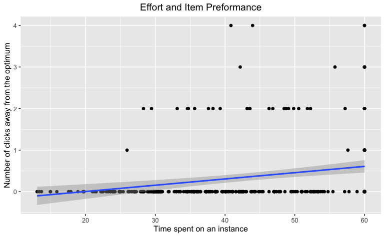

```r
plo = ggplot(data=dataOptTime, aes(x=timeSpent, y=itemDistanceFromOpt)) +
  geom_point()+
  labs(title="Effort and Item Preformance",x="Time spent on an instance",y="Number of clicks away from the optimum")+
  theme(plot.title = element_text(hjust = 0.5)) +
  stat_smooth(method = glm)

outputName = "opt14g"
plotExport(plo,outputName)
```

```r
cor.test(dataOptTime$timeSpent,dataOptTime$itemDistanceFromOpt)
```

```
    Pearson's product-moment correlation

data:  dataOptTime$timeSpent and dataOptTime$itemDistanceFromOpt
t = 4.3738, df = 303, p-value = 1.681e-05
alternative hypothesis: true correlation is not equal to 0
95 percent confidence interval:
 0.1350811 0.3465155
sample estimates:
      cor
0.2436916
```

```r
linearMRandomIntercept = lmer(itemDistanceFromOpt ~ timeSpent + (1|pID), data=dataOptTime)

title="Linear regressions"
tableName='opt14r'
modelTableStyle(linearMRandomIntercept,title,outputType,tableName)
```

[1] “opt14r” length of NULL cannot be changedlength of NULL cannot be changedlength of NULL cannot be changedlength of NULL cannot be changedlength of NULL cannot be changed

|  | Linear regressions |
| --- | --- |
|  | itemDistanceFromOpt |
|  | Random Intercept |
| timeSpent | 0.017*** |
|  | (0.004) |
|  | p = 0.00001 |
| Constant | -0.387** |
|  | (0.165) |
|  | p = 0.019 |
| Observations | 305 |
| Log Likelihood | -374.882 |
| Akaike Inf. Crit. | 757.765 |
| Bayesian Inf. Crit. | 772.646 |
| *Note:* | p<0.1; p<0.05; p<0.01 |

## 2.7 Time Spent and Accuracy (Computational Performance)

```
[1] "opt15g"
[1] "/Volumes/GoogleDrive/My Drive/Melbourne/UNIMELB/Research/Complexity Project/KS-IC/Code/Behavioural-Analysis/PNAS"
quartz_off_screen
                2
```

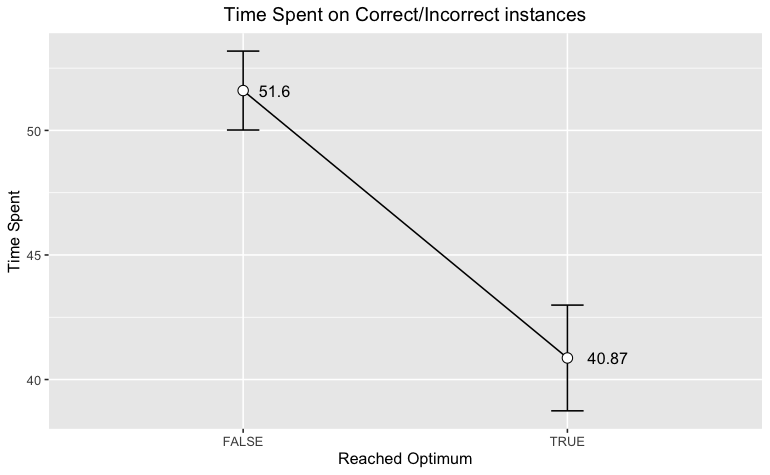

```r
dataInput= dataOptTime %>% group_by(correct,pID) %>% summarise(timeSpentMeans=mean(timeSpent)) %>% ungroup() %>% group_by(correct) %>%
  summarise(time=mean(timeSpentMeans),se=se(timeSpentMeans))%>%ungroup()
plo = ggplot(data=dataInput, aes(y=time, x=as.factor(as.logical(correct)), label = round(time,digits = 2),group=1)) +
  geom_line()+
  geom_errorbar(aes(ymin=time-se, ymax=time+se), width=.1) +
  geom_point(shape=21, size=3, fill="white")+
  labs(title="Time Spent on Correct/Incorrect instances",x="Reached Optimum",y="Time Spent") +
  theme(plot.title = element_text(hjust = 0.5), axis.text.x = element_text(angle=0,hjust=0.5))+
  geom_text(hjust=-0.5, colour="black")

outputName = "opt15g"
plotExport(plo,outputName)
```

```r
#Stats test for time in and out of phase transition: ANOVA
anovaModel=aov(timeSpent~correct+Error(pID/correct),dataOptTime)
anovaPValue=summary(anovaModel)[[2]][[1]][['Pr(>F)']][[1]]
print(paste("P-value for one way ANOVA:",signif(anovaPValue,digits=3)))
```

```
[1] "P-value for one way ANOVA: 1.27e-05"
```

```r
rm(dataInput)
```

```r
#Stats test for time for correct/incorrect answers
logitRandomIntercept = glmer(correct ~ timeSpent + (1|pID), family=binomial(link="logit"), data=dataOptTime)

title="Logistic regressions"
tableName='opt15r'
modelTableStyle(logitRandomIntercept,title,outputType,tableName)
```

[1] “opt15r” length of NULL cannot be changedlength of NULL cannot be changedlength of NULL cannot be changedlength of NULL cannot be changedlength of NULL cannot be changed

|  | Logistic regressions |
| --- | --- |
|  | correct |
|  | Random Intercept |
| timeSpent | -0.072*** |
|  | (0.017) |
|  | p = 0.00003 |
| Constant | 4.975*** |
|  | (0.865) |
|  | p = 0.000 |
| Observations | 305 |
| Log Likelihood | -124.754 |
| Akaike Inf. Crit. | 255.509 |
| Bayesian Inf. Crit. | 266.670 |
| *Note:* | p<0.1; p<0.05; p<0.01 |

### 2.7.1 Time Spent, Accuracy and IC

```
[1] "opt16g"
[1] "/Volumes/GoogleDrive/My Drive/Melbourne/UNIMELB/Research/Complexity Project/KS-IC/Code/Behavioural-Analysis/PNAS"
quartz_off_screen
                2
```

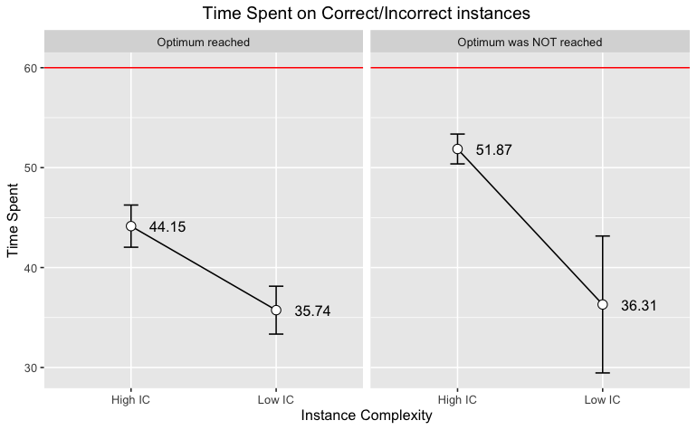

```r
dataInput= dataOptTime %>% group_by(correct,pID, phaseT) %>% summarise(timeSpentMeans=mean(timeSpent)) %>% ungroup() %>% group_by(correct,phaseT) %>%
  summarise(time=mean(timeSpentMeans),se=se(timeSpentMeans))%>%ungroup()
dataInput$phaseT = recode(dataInput$phaseT, '0' = "Low IC", '1' = "High IC")
dataInput$correct = recode(dataInput$correct, '0' = "Optimum was NOT reached", '1' = "Optimum reached")

plo = ggplot(data=dataInput, aes(y=time, x=as.factor(phaseT), label = round(time,digits = 2),group=1))+
  geom_line()+
  geom_errorbar(aes(ymin=time-se, ymax=time+se), width=.1) +
  geom_point(shape=21, size=3, fill="white")+
  labs(title="Time Spent on Correct/Incorrect instances",x="Instance Complexity",y="Time Spent") +
  theme(plot.title = element_text(hjust = 0.5), axis.text.x = element_text(angle=0,hjust=0.5))+
  geom_hline(aes(yintercept = 60),color = "red")+
  facet_grid(cols = vars(as.factor(correct)))+
  geom_text(hjust=-0.5, colour="black")



outputName = "opt16g"
plotExport(plo,outputName)
```

```r
#Stats test for time in and out of phase transition: ANOVA
anovaModel=aov(timeSpent~correct+Error(pID/correct),dataOptTime)
anovaPValue=summary(anovaModel)[[2]][[1]][['Pr(>F)']][[1]]
print(paste("P-value for one way ANOVA:",signif(anovaPValue,digits=3)))
```

```
[1] "P-value for one way ANOVA: 1.27e-05"
```

```r
rm(dataInput)
```

### 2.7.2 Controlling for effort, is Phase Transition still significant in the optimisation task?

```r
#Keeping timeSpent constant. is Phase transition effect on accuracy significant?
logitRandomIntercept = glmer(correct ~ phaseT + timeSpent + (1|pID), family=binomial(link="logit"), data=dataOptTime)

title="Logistic regressions"
tableName='app01r'
modelTableStyle(logitRandomIntercept,title,outputType,tableName)
```

[1] “app01r” length of NULL cannot be changedlength of NULL cannot be changedlength of NULL cannot be changedlength of NULL cannot be changedlength of NULL cannot be changed

|  | Logistic regressions |
| --- | --- |
|  | correct |
|  | Random Intercept |
| phaseT | -2.359*** |
|  | (0.743) |
|  | p = 0.002 |
| timeSpent | -0.055*** |
|  | (0.017) |
|  | p = 0.002 |
| Constant | 6.137*** |
|  | (1.062) |
|  | p = 0.000 |
| Observations | 305 |
| Log Likelihood | -115.648 |
| Akaike Inf. Crit. | 239.296 |
| Bayesian Inf. Crit. | 254.177 |
| *Note:* | p<0.1; p<0.05; p<0.01 |

### 2.7.3 Do people still modulate their effort when they don’t find the solution in the optimisation task?

```r
linearRandomIntercept = lmer(timeSpent ~ phaseT + correct + phaseT:correct + (1|pID), data=dataOptTime)

title="Linear regressions"
tableName='app03r'
modelTableStyle(linearRandomIntercept,title,outputType,tableName)
```

[1] “app03r” length of NULL cannot be changedlength of NULL cannot be changedlength of NULL cannot be changedlength of NULL cannot be changedlength of NULL cannot be changed

|  | Linear regressions |
| --- | --- |
|  | timeSpent |
|  | Random Intercept |
| phaseT | 15.161** |
|  | (7.261) |
|  | p = 0.037 |
| correct | -0.489 |
|  | (7.210) |
|  | p = 0.946 |
| phaseT:correct | -6.784 |
|  | (7.374) |
|  | p = 0.358 |
| Constant | 36.227*** |
|  | (7.379) |
|  | p = 0.00000 |
| Observations | 305 |
| Log Likelihood | -1,142.942 |
| Akaike Inf. Crit. | 2,297.885 |
| Bayesian Inf. Crit. | 2,320.207 |
| *Note:* | p<0.1; p<0.05; p<0.01 |

# 3 Comparison between Decision and Optimisation variants

```r
names(summaryListDec[[2]])['mean(correct)'==names(summaryListDec[[2]])]='AccuracyDecision'
names(summaryListOpt[[2]])['mean(correct)'==names(summaryListOpt[[2]])]='AccuracyOptimisation'

varMerge = merge(summaryListDec[[2]], summaryListOpt[[2]], by="pID")
varMerge_2 = varMerge %>% filter(pID != "be16")#Outlier

cortest = cor.test(varMerge$AccuracyDecision,varMerge$AccuracyOptimisation,method="pearson")#spearman is non-parametric
print(cortest)
```

```
    Pearson's product-moment correlation

data:  varMerge$AccuracyDecision and varMerge$AccuracyOptimisation
t = 2.4059, df = 18, p-value = 0.02709
alternative hypothesis: true correlation is not equal to 0
95 percent confidence interval:
 0.06494383 0.76813291
sample estimates:
     cor
0.493288
```

```r
cortest = cor.test(varMerge_2$AccuracyDecision,varMerge_2$AccuracyOptimisation,method="pearson")#spearman is non-parametric
print(cortest)
```

```
    Pearson's product-moment correlation

data:  varMerge_2$AccuracyDecision and varMerge_2$AccuracyOptimisation
t = 3.6993, df = 17, p-value = 0.001781
alternative hypothesis: true correlation is not equal to 0
95 percent confidence interval:
 0.3066136 0.8608933
sample estimates:
      cor
0.6678181
```

```
[1] "decOpt01g"
[1] "/Volumes/GoogleDrive/My Drive/Melbourne/UNIMELB/Research/Complexity Project/KS-IC/Code/Behavioural-Analysis/PNAS"
quartz_off_screen
                2
```

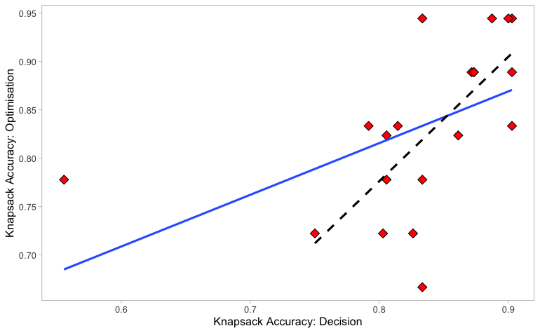

```r
plo = ggplot(varMerge,aes_string(x="AccuracyDecision",y="AccuracyOptimisation"))+
  geom_point(shape=23, size=3, fill="red") +
  geom_smooth(method="lm",se=FALSE,linetype="solid")+#GLM or LM(SAT...)
  labs(x="Knapsack Accuracy: Decision",y="Knapsack Accuracy: Optimisation")+
  theme_light()+
  theme(panel.grid.major = element_blank(),
        panel.grid.minor = element_blank(),
        plot.title = element_text(hjust = 0.5))+
  geom_smooth(data=varMerge_2, method="lm",se=FALSE,linetype="dashed",color='black')#GLM or LM(SAT...)


outputName = "decOpt01g"
plotExport(plo,outputName)
```

# 4 Arithmetic Task

First 3 trials where regarded as practice trials.

```r
dataMath = read_csv(fileDataMath)
#Filter First 3 trials of task; they were considered practice trials
dataMath=dataMath %>% filter( trial>= 4 | block != 1 )

summaryMath=dataMath %>% group_by(pID) %>% summarise(mean(correct), mean(timeSpent), mean(submitted))
names(summaryMath)['mean(correct)'==names(summaryMath)]='AccuracyMath'
```

```r
print(paste('Number of participants to analyse:',length(unique(dataMath$pID)) ) )
```

```
[1] "Number of participants to analyse: 20"
```

```r
print(paste('Participants To be analysed are:',paste(unique(dataMath$pID),collapse=" ")))
```

```
[1] "Participants To be analysed are: be14 be15 be16 be17 be18 be19 be20 be21 be22 be23 be24 be25 be26 be27 be28 be29 be30 be31 be32 be33"
```

```r
print(paste("The overall MATH accuracy is",mean(dataMath$correct)))
```

```
[1] "The overall MATH accuracy is 0.628333333333333"
```

## 4.1 Accuracy in Decision Knapsack problem and Mental Arithmetic

```
[1] "math01g"
[1] "/Volumes/GoogleDrive/My Drive/Melbourne/UNIMELB/Research/Complexity Project/KS-IC/Code/Behavioural-Analysis/PNAS"
quartz_off_screen
                2
```

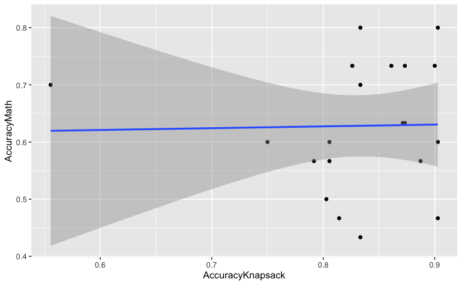

```r
names(summaryListDec[[2]])['AccuracyDecision'==names(summaryListDec[[2]])]='AccuracyKnapsack'
mathMerge = merge(summaryListDec[[2]], summaryMath, by="pID")

#mathMerge = mathMerge %>% filter(pID != "be16")

plo =  ggplot(mathMerge,aes(x=AccuracyKnapsack,y=AccuracyMath))+
  geom_point() +
  geom_smooth(method="lm")#GLM or LM(SAT...)


outputName = "math01g"
plotExport(plo,outputName)
```

```r
mathDec = cor.test(mathMerge$AccuracyKnapsack,mathMerge$AccuracyMath,method="pearson")#spearman is non-parametric vs. pearson which is parametric (linear)
```

## 4.2 Accuracy in Optimisation Knapsack problem and Mental Arithmetic

```
[1] "math02g"
[1] "/Volumes/GoogleDrive/My Drive/Melbourne/UNIMELB/Research/Complexity Project/KS-IC/Code/Behavioural-Analysis/PNAS"
quartz_off_screen
                2
```

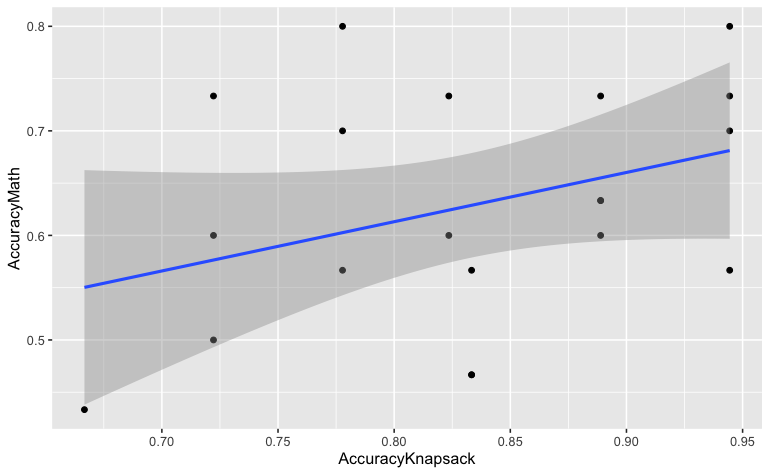

```r
#Accuracy of Knapsack vs. Math Task Accuracy
names(summaryListOpt[[2]])['AccuracyOptimisation'==names(summaryListOpt[[2]])]='AccuracyKnapsack'
mathMerge = merge(summaryListOpt[[2]], summaryMath, by="pID")

plo = ggplot(mathMerge,aes(x=AccuracyKnapsack,y=AccuracyMath))+
  geom_point() +
  geom_smooth(method="lm")

outputName = "math02g"
plotExport(plo,outputName)
```

```r
mathOpt =cor.test(mathMerge$AccuracyKnapsack,mathMerge$AccuracyMath,method="pearson")#spearman is non-parametric
```

# 5 CANTAB Tasks

```r
#CANTAB Data import
dataCantabWork = read_csv(fileDataCantab)
variables=names(dataCantabWork)[-1]
```

```
[1] "PALFAMS28"

    Pearson's product-moment correlation

data:  varMerge$AccuracyKnapsack and varMerge[[varName]]
t = -0.70897, df = 18, p-value = 0.4874
alternative hypothesis: true correlation is not equal to 0
95 percent confidence interval:
 -0.5660547  0.2995489
sample estimates:
       cor
-0.1648198

[1] "PALTEA28"

    Pearson's product-moment correlation

data:  varMerge$AccuracyKnapsack and varMerge[[varName]]
t = 0.97495, df = 18, p-value = 0.3425
alternative hypothesis: true correlation is not equal to 0
95 percent confidence interval:
 -0.2426034  0.6063847
sample estimates:
      cor
0.2239612

[1] "SSPFSL"

    Pearson's product-moment correlation

data:  varMerge$AccuracyKnapsack and varMerge[[varName]]
t = -0.39398, df = 18, p-value = 0.6982
alternative hypothesis: true correlation is not equal to 0
95 percent confidence interval:
 -0.5139561  0.3649901
sample estimates:
        cor
-0.09246525

[1] "SWMS"
```

[output cut: 22 more lines]

```
       cor
-0.1285963

[1] "SWMBEweightedJP"

    Pearson's product-moment correlation

data:  varMerge$AccuracyKnapsack and varMerge[[varName]]
t = -0.65695, df = 18, p-value = 0.5195
alternative hypothesis: true correlation is not equal to 0
95 percent confidence interval:
 -0.5577718  0.3105278
sample estimates:
       cor
-0.1530203
```

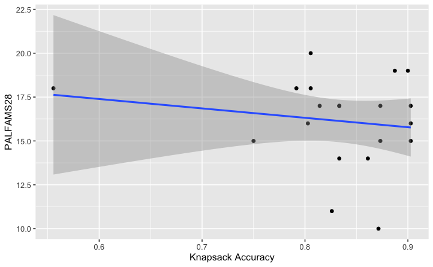

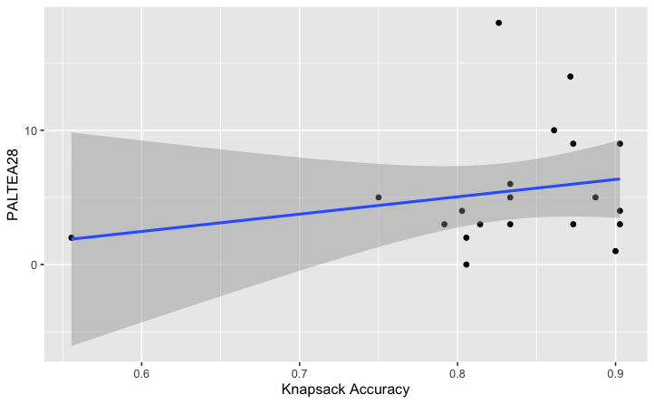

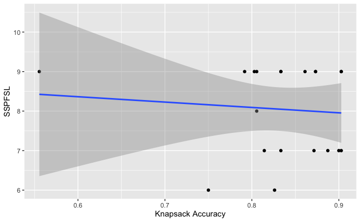

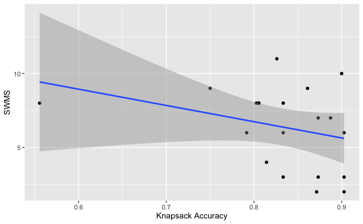

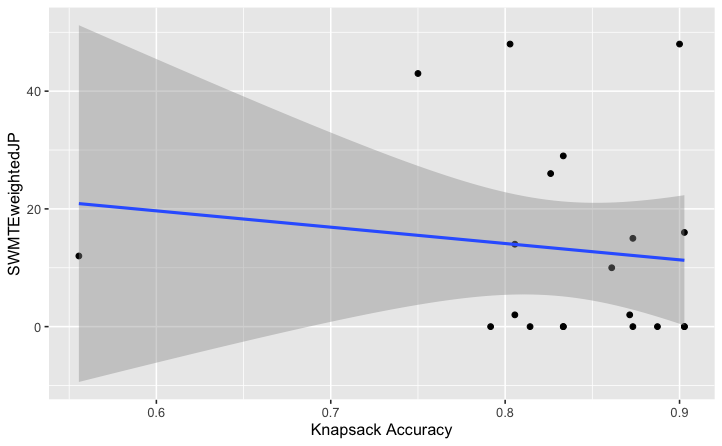

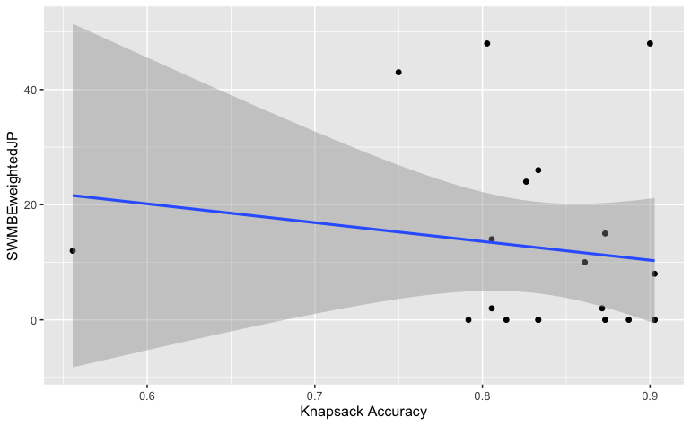

```r
#Analysis of a variables and mean Decision KS accuracy
decResults=list()
for (i in 1:length(variables)){
  #print(i)
  summaryVar=dataCantabWork[,c("pID",variables[i])]
  #summaryVar=dataCantabWork[,c("subject.ID","SSPFSL")]
  names(summaryVar)[1]="pID"
  decResults[[i]]=indDiffAnalysis(summaryVar,dataDecProp)
}
```